# Vegetation classification of Singapore’s forests using LTFEM plots

# Clustering

## Using species composition

### Of trees

#### By occurrence

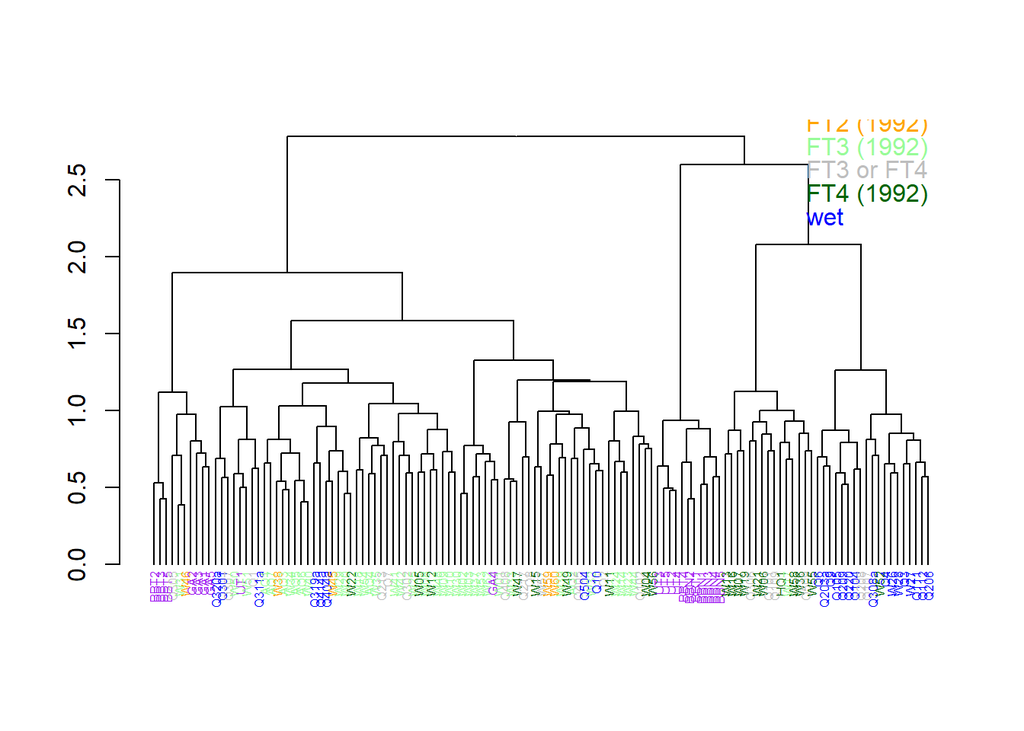

```r
treeComm_occ_hclust <- treeComm_occ %>%
    vegdist(method = "bray") %>%
    hclust(method = "ward.D2")

treeComm_occ_dendro <- treeComm_occ_hclust %>%
    as.dendrogram() %>%
    color_labels(col = col_plotType[
        match(treeComm_occ_hclust$labels, plots$plotID)
    ][treeComm_occ_hclust$order])

labels_cex(treeComm_occ_dendro) <- 0.5

plot(treeComm_occ_dendro)
legend(x = 100, y = 3.2,
       legend = c("Nature Parks",
                  "FT2 (1992)",
                  "FT3 (1992)",
                  "FT3 or FT4",
                  "FT4 (1992)",
                  "wet"),
       bty = "n",
       text.col = c("purple", "orange", "palegreen", "grey", "darkgreen",
                    "blue"),
       y.intersp = 0.8)
```

#### By stem counts

```r
treeComm_stem_hclust <- treeComm_stem %>%
    vegdist(method = "bray") %>%
    hclust(method = "ward.D2")

treeComm_stem_dendro <- treeComm_stem_hclust %>%
    as.dendrogram() %>%
    color_labels(col = col_plotType[
        match(treeComm_stem_hclust$labels, plots$plotID)
    ][treeComm_stem_hclust$order])

labels_cex(treeComm_stem_dendro) <- 0.5

treeComm_stem_clusters <- cutree(treeComm_stem_hclust, k = 4)

png("../../out/graphs/LTFEM_Veg_Classification_treeComm_stem.png",
    width = 25, height = 20, units = "cm", res = 300)

plot(treeComm_stem_dendro);
rect.dendrogram(treeComm_stem_dendro,
                k = 4,
                # text = c("Group 2",
                #          "Group 1",
                #          "Group 3",
                #          "Group 4"),
                lower_rect = -0.01);
legend(x = 90, y = 3.3,
       legend = c("Nature Parks",
                  "WYK FT2 (1992)",
                  "WYK FT3 (1992)",
                  "NSSF dry - either FT3 or FT4",
                  "WYK FT4 (1992) excl. wet",
                  "WYK and NSSF wet"),
       bty = "n",
       text.col = c("purple", "orange", "palegreen", "grey", "darkgreen",
                    "blue"),
       y.intersp = 0.8)

dev.off()
```

#### By basal area

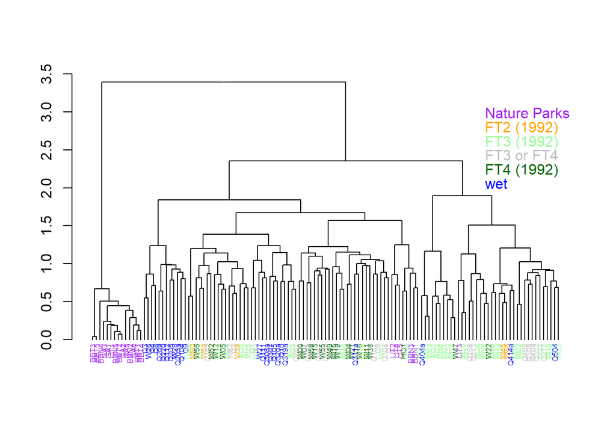

```r
treeComm_basalArea_hclust <- treeComm_basalArea %>%
    vegdist(method = "bray") %>%
    hclust(method = "ward.D2")

treeComm_basalArea_dendro <- treeComm_basalArea_hclust %>%
    as.dendrogram() %>%
    color_labels(col = col_plotType[
        match(treeComm_basalArea_hclust$labels, plots$plotID)
    ][treeComm_basalArea_hclust$order])

labels_cex(treeComm_basalArea_dendro) <- 0.5

plot(treeComm_basalArea_dendro)
legend(x = 100, y = 3.2,
       legend = c("Nature Parks",
                  "FT2 (1992)",
                  "FT3 (1992)",
                  "FT3 or FT4",
                  "FT4 (1992)",
                  "wet"),
       bty = "n",
       text.col = c("purple", "orange", "palegreen", "grey", "darkgreen",
                    "blue"),
       y.intersp = 0.8)
```

### Of big trees

#### By occurrence

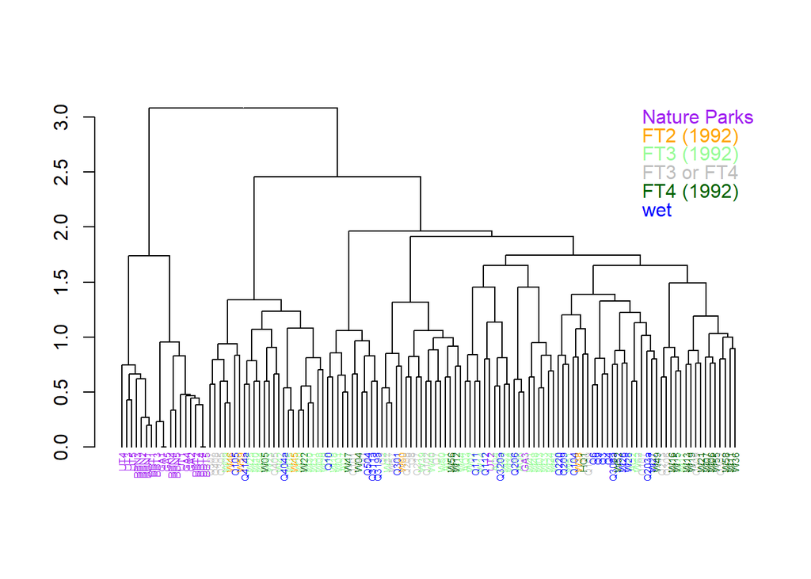

```r
bigTreeComm_occ_hclust <- bigTreeComm_occ %>%
    vegdist(method = "bray") %>%
    hclust(method = "ward.D2")

bigTreeComm_occ_dendro <- bigTreeComm_occ_hclust %>%
    as.dendrogram() %>%
    color_labels(col = col_plotType[
        match(bigTreeComm_occ_hclust$labels, plots$plotID)
    ][bigTreeComm_occ_hclust$order])

labels_cex(bigTreeComm_occ_dendro) <- 0.5

plot(bigTreeComm_occ_dendro)
legend(x = 100, y = 3.2,
       legend = c("Nature Parks",
                  "FT2 (1992)",
                  "FT3 (1992)",
                  "FT3 or FT4",
                  "FT4 (1992)",
                  "wet"),
       bty = "n",
       text.col = c("purple", "orange", "palegreen", "grey", "darkgreen",
                    "blue"),
       y.intersp = 0.8)
```

#### By stem counts

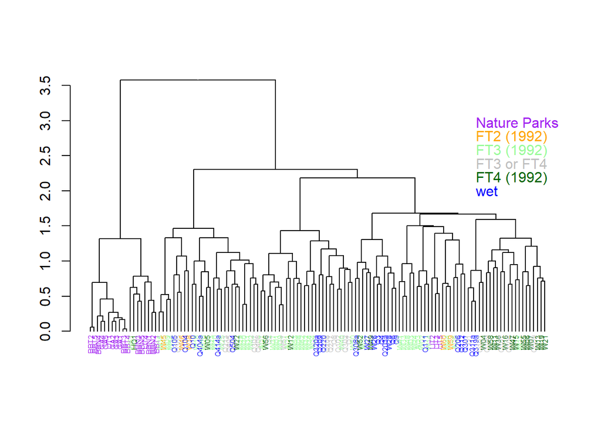

```r
bigTreeComm_stem_hclust <- bigTreeComm_stem %>%
    vegdist(method = "bray") %>%
    hclust(method = "ward.D2")

bigTreeComm_stem_dendro <- bigTreeComm_stem_hclust %>%
    as.dendrogram() %>%
    color_labels(col = col_plotType[
        match(bigTreeComm_stem_hclust$labels, plots$plotID)
    ][bigTreeComm_stem_hclust$order])

labels_cex(bigTreeComm_stem_dendro) <- 0.5

plot(bigTreeComm_stem_dendro)
legend(x = 100, y = 3.2,
       legend = c("Nature Parks",
                  "FT2 (1992)",
                  "FT3 (1992)",
                  "FT3 or FT4",
                  "FT4 (1992)",
                  "wet"),
       bty = "n",
       text.col = c("purple", "orange", "palegreen", "grey", "darkgreen",
                    "blue"),
       y.intersp = 0.8)
```

#### By basal area

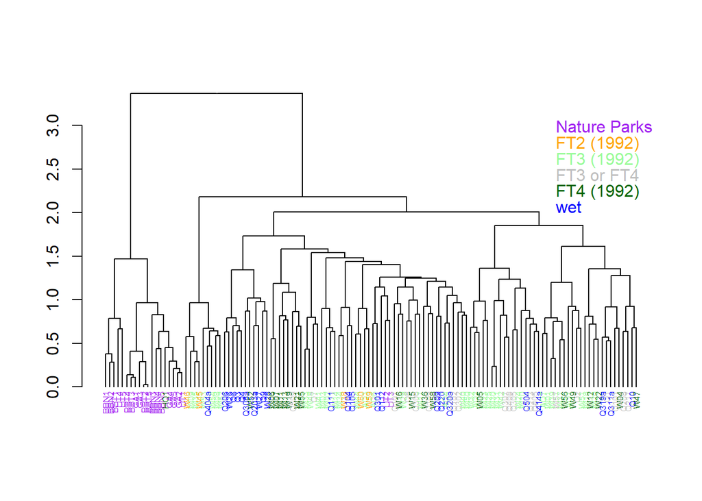

```r
bigTreeComm_basalArea_hclust <- bigTreeComm_basalArea %>%
    vegdist(method = "bray") %>%
    hclust(method = "ward.D2")

bigTreeComm_basalArea_dendro <- bigTreeComm_basalArea_hclust %>%
    as.dendrogram() %>%
    color_labels(col = col_plotType[
        match(bigTreeComm_basalArea_hclust$labels, plots$plotID)
    ][bigTreeComm_basalArea_hclust$order])

labels_cex(bigTreeComm_basalArea_dendro) <- 0.5

plot(bigTreeComm_basalArea_dendro)
legend(x = 100, y = 3.2,
       legend = c("Nature Parks",
                  "FT2 (1992)",
                  "FT3 (1992)",
                  "FT3 or FT4",
                  "FT4 (1992)",
                  "wet"),
       bty = "n",
       text.col = c("purple", "orange", "palegreen", "grey", "darkgreen",
                    "blue"),
       y.intersp = 0.8)
```

## Using phylogenetic composition

Of trees.

### By occurrence

```r
treeComm_occ_r <- apply(treeComm_occ, 1, function(x) x/sum(x)) %>%
    t()

treeComm_occ_f <- treeComm_occ_r %*% spp_pcnm_scores
```

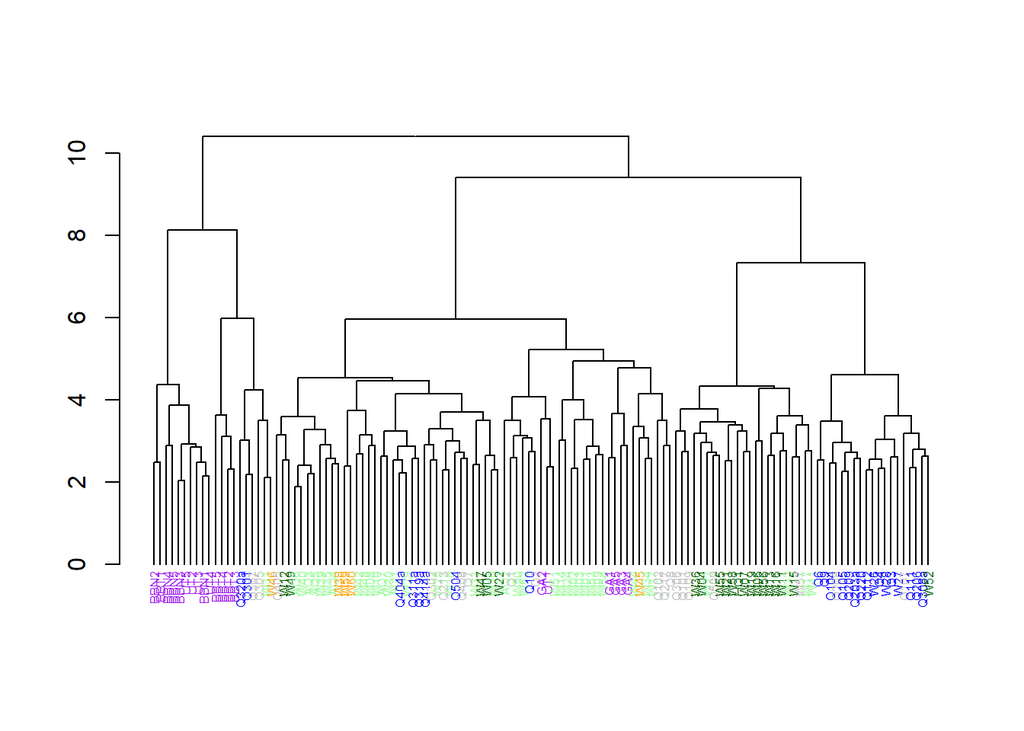

```r
treeComm_occ_f_hclust <- treeComm_occ_f %>%
    vegdist(method = "manhattan") %>%
    hclust(method = "ward.D2")

treeComm_occ_f_dendro <- treeComm_occ_f_hclust %>%
    as.dendrogram() %>%
    color_labels(col = col_plotType[match(treeComm_occ_f_hclust$labels, plots$plotID)][treeComm_occ_f_hclust$order])

labels_cex(treeComm_occ_f_dendro) <- 0.5

plot(treeComm_occ_f_dendro)
```

### By stem counts

```r
treeComm_stem_r <- apply(treeComm_stem, 1, function(x) x/sum(x)) %>%
    t()

treeComm_stem_f <- treeComm_stem_r %*% spp_pcnm_scores
```

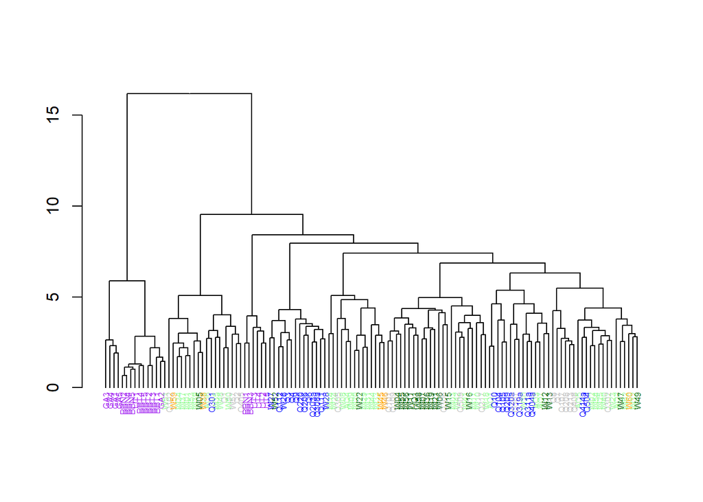

```r
treeComm_stem_f_hclust <- treeComm_stem_f %>%
    vegdist(method = "manhattan") %>%
    hclust(method = "ward.D2")

treeComm_stem_f_dendro <- treeComm_stem_f_hclust %>%
    as.dendrogram() %>%
    color_labels(col = col_plotType[match(treeComm_stem_f_hclust$labels, plots$plotID)][treeComm_stem_f_hclust$order])

labels_cex(treeComm_stem_f_dendro) <- 0.5

plot(treeComm_stem_f_dendro)
```

### By basal area

```r
treeComm_basalArea_r <- apply(treeComm_basalArea, 1, function(x) x/sum(x)) %>%
    t()

treeComm_basalArea_f <- treeComm_basalArea_r %*% spp_pcnm_scores
```

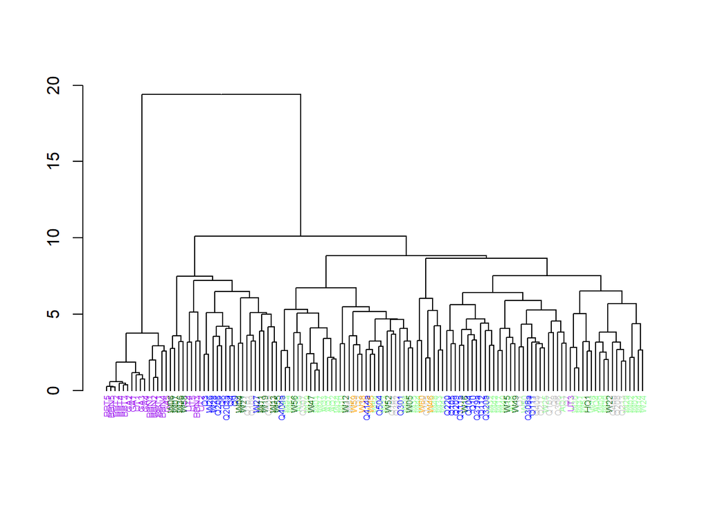

```r
treeComm_basalArea_f_hclust <- treeComm_basalArea_f %>%
    vegdist(method = "manhattan") %>%
    hclust(method = "ward.D2")

treeComm_basalArea_f_dendro <- treeComm_basalArea_f_hclust %>%
    as.dendrogram() %>%
    color_labels(col = col_plotType[match(treeComm_basalArea_f_hclust$labels, plots$plotID)][treeComm_basalArea_f_hclust$order])

labels_cex(treeComm_basalArea_f_dendro) <- 0.5

plot(treeComm_basalArea_f_dendro)
```

# Indicator species analysis

```r
treeComm_stem_clusters_isa <- indicspecies::multipatt(treeComm_stem,
                                                      treeComm_stem_clusters)
```

## Primary forest

### Non-swamp

```r
treeComm_stem_clusters_isa$sign %>%
    filter(s.1 == 0 & s.2 == 0 & s.3 == 1 & s.4 == 0,
           p.value <= 0.05) %>%
    rownames_to_column(var = "species") %>%
    left_join(select(flora, species, family), by = "species") %>%
    select(species, family, stat, p.value) %>%
    arrange(family) %>%
    rename(Species = species,
           Family = family,
           `Indicator Value` = stat,
           `p-value` = p.value)
```

| Species | Family | Indicator Value | p-value |
| --- | --- | --- | --- |
| Parishia maingayi var. maingayi | Anacardiaceae | 0.4170288 | 0.005 |
| Monoon borneense | Annonaceae | 0.3611576 | 0.010 |
| Polyalthia angustissima | Annonaceae | 0.3611576 | 0.010 |
| Popowia fusca | Annonaceae | 0.5271459 | 0.005 |
| Dyera costulata | Apocynaceae | 0.4479608 | 0.005 |
| Canarium patentinervium | Burseraceae | 0.3891949 | 0.020 |
| Dacryodes costata | Burseraceae | 0.5107539 | 0.005 |
| Santiria griffithii | Burseraceae | 0.5024484 | 0.005 |
| Gironniera subaequalis | Cannabaceae | 0.4316658 | 0.005 |
| Dipterocarpus grandiflorus | Dipterocarpaceae | 0.2948839 | 0.050 |
| Hopea griffithii | Dipterocarpaceae | 0.4170288 | 0.005 |
| Rubroshorea macroptera | Dipterocarpaceae | 0.4170288 | 0.010 |
| Rubroshorea pauciflora | Dipterocarpaceae | 0.4363075 | 0.005 |
| Diospyros venosa | Ebenaceae | 0.3606276 | 0.040 |
| Croton laevifolius | Euphorbiaceae | 0.3611576 | 0.005 |
| Koilodepas longifolium | Euphorbiaceae | 0.4361392 | 0.005 |
| Adenanthera malayana subsp. malayana | Fabaceae | 0.4256283 | 0.020 |
| Koompassia malaccensis | Fabaceae | 0.3860937 | 0.005 |
| Teijsmanniodendron coriaceum | Lamiaceae | 0.2948839 | 0.040 |
| Nothaphoebe umbelliflora | Lauraceae | 0.4839940 | 0.020 |
| Aglaia sp. | Meliaceae | 0.3426241 | 0.030 |
| Epicharis cuneata | Meliaceae | 0.4532491 | 0.005 |
| Sandoricum koetjape | Meliaceae | 0.3496893 | 0.030 |
| Antidesma coriaceum | Phyllanthaceae | 0.4170288 | 0.005 |
| Antidesma cuspidatum | Phyllanthaceae | 0.5788311 | 0.005 |
| Aporosa prainiana | Phyllanthaceae | 0.4662524 | 0.005 |
| Aporosa symplocoides | Phyllanthaceae | 0.6951352 | 0.005 |
| Baccaurea parviflora | Phyllanthaceae | 0.6117406 | 0.005 |
| Xanthophyllum eurhynchum | Polygalaceae | 0.5396325 | 0.005 |
| Drypetes pendula | Putranjivaceae | 0.3469890 | 0.035 |
| Glycosmis chlorosperma | Rutaceae | 0.4593290 | 0.005 |
| Xerospermum noronhianum | Sapindaceae | 0.4662524 | 0.005 |

### Freshwater swamp

```r
treeComm_stem_clusters_isa$sign %>%
    filter(s.1 == 0 & s.2 == 0 & s.3 == 0 & s.4 == 1,
           p.value <= 0.05) %>%
    rownames_to_column(var = "species") %>%
    left_join(select(flora, species, family), by = "species") %>%
    select(species, family, stat, p.value) %>%
    arrange(family) %>%
    rename(Species = species,
           Family = family,
           `Indicator Value` = stat,
           `p-value` = p.value)
```

| Species | Family | Indicator Value | p-value |
| --- | --- | --- | --- |
| Campnosperma squamatum | Anacardiaceae | 0.6826471 | 0.005 |
| Gluta wallichii | Anacardiaceae | 0.5044935 | 0.005 |
| Melanochyla caesia | Anacardiaceae | 0.6416889 | 0.005 |
| Maasia glauca | Annonaceae | 0.4495543 | 0.010 |
| Kopsia singapurensis | Apocynaceae | 0.4200840 | 0.005 |
| Ilex cymosa | Aquifoliaceae | 0.4077152 | 0.005 |
| Radermachera quadripinnata | Bignoniaceae | 0.6416889 | 0.005 |
| Dacryodes incurvata | Burseraceae | 0.3236415 | 0.040 |
| Calophyllum dispar | Calophyllaceae | 0.3429972 | 0.030 |
| Calophyllum rufigemmatum | Calophyllaceae | 0.3762803 | 0.025 |
| Lophopetalum multinervium | Celastraceae | 0.6416889 | 0.005 |
| Alangium denudatum | Cornaceae | 0.3429972 | 0.010 |
| Rubroshorea platycarpa | Dipterocarpaceae | 0.4576982 | 0.010 |
| Vatica pauciflora | Dipterocarpaceae | 0.4850713 | 0.005 |
| Diospyros lanceifolia | Ebenaceae | 0.6361161 | 0.005 |
| Diospyros maingayi | Ebenaceae | 0.3236415 | 0.020 |
| Diospyros oblonga | Ebenaceae | 0.7669650 | 0.005 |
| Elaeocarpus griffithii | Elaeocarpaceae | 0.3429972 | 0.020 |
| Blumeodendron tokbrai | Euphorbiaceae | 0.4200840 | 0.005 |
| Macaranga recurvata | Euphorbiaceae | 0.6472830 | 0.005 |
| Neoscortechinia sumatrensis | Euphorbiaceae | 0.6416889 | 0.005 |
| Alseodaphne bancana | Lauraceae | 0.5423261 | 0.005 |
| Beilschmiedia kunstleri | Lauraceae | 0.4077152 | 0.020 |
| Cryptocarya ferrea | Lauraceae | 0.5940885 | 0.005 |
| Litsea erectinervia | Lauraceae | 0.5940885 | 0.005 |
| Magnolia singapurensis | Magnoliaceae | 0.6859943 | 0.005 |
| Neesia malayana | Malvaceae | 0.4850713 | 0.005 |
| Scaphium affine | Malvaceae | 0.4261489 | 0.010 |
| Sterculia cordata | Malvaceae | 0.3429972 | 0.020 |
| Sterculia gilva | Malvaceae | 0.3151165 | 0.045 |
| Pternandra coerulescens | Melastomataceae | 0.7691153 | 0.005 |
| Sandoricum beccarianum | Meliaceae | 0.4850713 | 0.005 |
| Artocarpus kemando | Moraceae | 0.4144901 | 0.010 |
| Gymnacranthera forbesii | Myristicaceae | 0.4456421 | 0.010 |
| Horsfieldia crassifolia | Myristicaceae | 0.7032749 | 0.005 |
| Horsfieldia polyspherula var. polyspherula | Myristicaceae | 0.4705214 | 0.010 |
| Horsfieldia sparsa | Myristicaceae | 0.4707890 | 0.005 |
| Knema conferta | Myristicaceae | 0.5562230 | 0.005 |
| Knema curtisii var. paludosa | Myristicaceae | 0.4456421 | 0.010 |
| Knema latericia subsp. ridleyi | Myristicaceae | 0.6289767 | 0.005 |
| Knema sumatrana | Myristicaceae | 0.3429972 | 0.035 |
| Myristica elliptica | Myristicaceae | 0.5423261 | 0.005 |
| Syzygium formosum | Myrtaceae | 0.5380827 | 0.005 |
| Syzygium incarnatum | Myrtaceae | 0.4764489 | 0.005 |
| Syzygium papillosum | Myrtaceae | 0.3178829 | 0.035 |
| Syzygium polyanthum | Myrtaceae | 0.3429972 | 0.025 |
| Mastixia trichotoma var. maingayi | Nyssaceae | 0.5940885 | 0.005 |
| Strombosia ceylanica | Olacaceae | 0.7567357 | 0.005 |
| Benstonea atrocarpa | Pandanaceae | 0.4831551 | 0.005 |
| Aporosa falcifera | Phyllanthaceae | 0.5895666 | 0.005 |
| Baccaurea bracteata | Phyllanthaceae | 0.7047246 | 0.005 |
| Baccaurea polyneura | Phyllanthaceae | 0.4764489 | 0.005 |
| Glochidion rubrum | Phyllanthaceae | 0.3429972 | 0.025 |
| Xanthophyllum flavescens | Polygalaceae | 0.5522788 | 0.045 |
| Pellacalyx axillaris | Rhizophoraceae | 0.5592023 | 0.005 |
| Mussaendopsis beccariana | Rubiaceae | 0.5940885 | 0.005 |
| Timonius flavescens | Rubiaceae | 0.5102005 | 0.005 |
| Osmelia grandistipulata | Salicaceae | 0.6215942 | 0.005 |
| Nephelium laurinum | Sapindaceae | 0.4077152 | 0.005 |
| Pometia pinnata | Sapindaceae | 0.9074852 | 0.005 |
| Madhuca sp. 1 | Sapotaceae | 0.6377727 | 0.005 |
| Palaquium xanthochymum | Sapotaceae | 0.7276069 | 0.005 |

### Both

```r
treeComm_stem_clusters_isa$sign %>%
    filter(s.1 == 0 & s.2 == 0 & s.3 == 1 & s.4 == 1,
           p.value <= 0.05) %>%
    rownames_to_column(var = "species") %>%
    left_join(select(flora, species, family), by = "species") %>%
    select(species, family, stat, p.value) %>%
    arrange(family) %>%
    rename(Species = species,
           Family = family,
           `Indicator Value` = stat,
           `p-value` = p.value)
```

| Species | Family | Indicator Value | p-value |
| --- | --- | --- | --- |
| Canarium littorale | Burseraceae | 0.3742697 | 0.020 |
| Dacryodes rostrata | Burseraceae | 0.3814062 | 0.035 |
| Pimelodendron griffithianum | Euphorbiaceae | 0.5000000 | 0.005 |
| Lithocarpus encleisacarpus | Fagaceae | 0.3162278 | 0.050 |
| Gymnacranthera farquhariana | Myristicaceae | 0.3909601 | 0.030 |
| Knema communis | Myristicaceae | 0.4432327 | 0.030 |

## Native-dominated forest

### Secondary only

```r
treeComm_stem_clusters_isa$sign %>%
    filter(s.1 == 1 & s.2 == 0 & s.3 == 0 & s.4 == 0,
           p.value <= 0.05) %>%
    rownames_to_column(var = "species") %>%
    left_join(select(flora, species, family), by = "species") %>%
    select(species, family, stat, p.value) %>%
    arrange(family) %>%
    rename(Species = species,
           Family = family,
           `Indicator Value` = stat,
           `p-value` = p.value)
```

| Species | Family | Indicator Value | p-value |
| --- | --- | --- | --- |
| Pternandra echinata | Melastomataceae | 0.4907165 | 0.030 |
| Prunus polystachya | Rosaceae | 0.7360655 | 0.005 |

### Secondary + primary but not swamp

```r
treeComm_stem_clusters_isa$sign %>%
    filter(s.1 == 1 & s.2 == 0 & s.3 == 1 & s.4 == 0,
           p.value <= 0.05) %>%
    rownames_to_column(var = "species") %>%
    left_join(select(flora, species, family), by = "species") %>%
    select(species, family, stat, p.value) %>%
    arrange(family) %>%
    rename(Species = species,
           Family = family,
           `Indicator Value` = stat,
           `p-value` = p.value)
```

| Species | Family | Indicator Value | p-value |
| --- | --- | --- | --- |
| Gironniera nervosa | Cannabaceae | 0.7961308 | 0.005 |
| Litsea elliptica | Lauraceae | 0.5107539 | 0.025 |
| Timonius wallichianus | Rubiaceae | 0.8001552 | 0.005 |

### Secondary + primary including swamp

```r
treeComm_stem_clusters_isa$sign %>%
    filter(s.1 == 1 & s.2 == 0 & s.3 == 1 & s.4 == 1,
           p.value <= 0.05) %>%
    rownames_to_column(var = "species") %>%
    left_join(select(flora, species, family), by = "species") %>%
    select(species, family, stat, p.value) %>%
    arrange(family) %>%
    rename(Species = species,
           Family = family,
           `Indicator Value` = stat,
           `p-value` = p.value)
```

| Species | Family | Indicator Value | p-value |
| --- | --- | --- | --- |
| Garcinia parvifolia | Clusiaceae | 0.6285263 | 0.015 |
| Gynotroches axillaris | Rhizophoraceae | 0.6284788 | 0.035 |

## Abandoned-land forest

```r
treeComm_stem_clusters_isa$sign %>%
    filter(s.1 == 0 & s.2 == 1 & s.3 == 0 & s.4 == 0,
           p.value <= 0.05) %>%
    rownames_to_column(var = "species") %>%
    left_join(select(flora, species, family), by = "species") %>%
    select(species, family, stat, p.value) %>%
    arrange(family) %>%
    rename(Species = species,
           Family = family,
           `Indicator Value` = stat,
           `p-value` = p.value)
```

| Species | Family | Indicator Value | p-value |
| --- | --- | --- | --- |
| Areca catechu | Arecaceae | 0.3333333 | 0.030 |
| Caryota mitis | Arecaceae | 0.6000513 | 0.005 |
| Ptychosperma macarthurii | Arecaceae | 0.3333333 | 0.025 |
| Dracaena fragrans | Asparagaceae | 0.4082483 | 0.005 |
| Spathodea campanulata | Bignoniaceae | 0.4614791 | 0.005 |
| Dillenia suffruticosa | Dilleniaceae | 0.4082483 | 0.010 |
| Claoxylon indicum | Euphorbiaceae | 0.3333333 | 0.025 |
| Hevea brasiliensis | Euphorbiaceae | 0.9570302 | 0.005 |
| Andira inermis | Fabaceae | 0.3979977 | 0.005 |
| Cinnamomum iners | Lauraceae | 0.6623384 | 0.005 |
| Artocarpus heterophyllus | Moraceae | 0.5618597 | 0.005 |
| Artocarpus integer | Moraceae | 0.5138129 | 0.005 |
| Ficus fistulosa | Moraceae | 0.4561836 | 0.005 |
| Ficus variegata | Moraceae | 0.3955535 | 0.015 |
| Syzygium sp. | Myrtaceae | 0.3197221 | 0.045 |
| Eurya acuminata | Pentaphylacaceae | 0.3333333 | 0.035 |
| Nephelium lappaceum | Sapindaceae | 0.6568542 | 0.005 |
| Nephelium ramboutan-ake | Sapindaceae | 0.3333333 | 0.040 |

# Forest structure and diversity

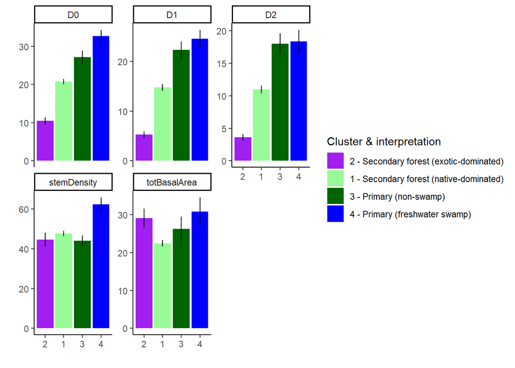

```r
plots <- plots %>%
    left_join(
        data.frame(stemDensity = rowSums(treeComm_stem),
                   totBasalArea = rowSums(treeComm_basalArea)/400,
                   D0 = specnumber(treeComm_stem),
                   D1 = exp(diversity(treeComm_stem, index = "shannon")),
                   D2 = diversity(treeComm_stem, index = "invsimpson")) %>%
            rownames_to_column(var = "plotID"),
        by = "plotID") %>%
    left_join(data.frame(cluster = treeComm_stem_clusters) %>%
                  rownames_to_column(var = "plotID"),
              by = "plotID")

fun_se <- function(x) sd(x)/sqrt(length(x))

plots_summary <- plots %>%
    filter(!is.na(cluster)) %>%
    group_by(cluster) %>%
    summarise(stemDensity_mean = mean(stemDensity),
              stemDensity_se = fun_se(stemDensity),
              totBasalArea_mean = mean(totBasalArea),
              totBasalArea_se = fun_se(totBasalArea),
              D0_mean = mean(D0),
              D0_se = fun_se(D0),
              D1_mean = mean(D1),
              D1_se = fun_se(D1),
              D2_mean = mean(D2),
              D2_se = fun_se(D2)) %>%
    mutate(cluster = as.factor(cluster)) %>%
    mutate(cluster = factor(cluster, levels = c(2,1,3,4)))

ggplot(plots_summary %>%
           pivot_longer(cols = -cluster) %>%
           separate(name, into = c("var", "stat")) %>%
           pivot_wider(names_from = stat, values_from = value),
       aes(x = cluster, fill = cluster)) +
    geom_col(aes(y = mean)) +
    geom_segment(aes(xend = cluster, y = mean - se, yend = mean + se)) +
    facet_wrap(~var, scales = "free_y") +
    scale_fill_manual(
        name = "Cluster & interpretation",
        labels = c("2 - Secondary forest (exotic-dominated)",
                   "1 - Secondary forest (native-dominated)",
                   "3 - Primary (non-swamp)",
                   "4 - Primary (freshwater swamp)"),
        values = c("purple", "palegreen", "darkgreen", "blue")
        ) +
    labs(x = "", y = "") +
    theme_classic()
```

# Tree floristics

## By stem counts

```r
treeComm_stem_floristics <- treeComm_stem %>%
    as.data.frame() %>%
    rownames_to_column(var = "plotID") %>%
    left_join(plots %>% select(plotID, cluster),
              by = "plotID") %>%
    select(-plotID) %>%
    group_by(cluster) %>%
    summarise_all(function(x) sum(x)/length(x)/(0.04))
```

### Primary (non-swamp) forest

```r
treeComm_stem_floristics %>%
    filter(cluster == 3) %>%
    select(-cluster) %>%
    t() %>%
    as.data.frame() %>%
    arrange(desc(V1)) %>%
    rownames_to_column(var = "species") %>%
    head(10) %>%
    left_join(select(flora, species, family), by = "species") %>%
    select(species, family, V1) %>%
    rename(`No. of stems per ha` = V1)
```

| species | family | No. of stems per ha |
| --- | --- | --- |
| Aporosa symplocoides | Phyllanthaceae | 46.73913 |
| Gironniera nervosa | Cannabaceae | 27.17391 |
| Knema malayana | Myristicaceae | 26.08696 |
| Sloetia elongata | Moraceae | 26.08696 |
| Strombosia ceylanica | Olacaceae | 23.91304 |
| Baccaurea parviflora | Phyllanthaceae | 22.82609 |
| Epicharis cuneata | Meliaceae | 19.56522 |
| Glycosmis chlorosperma | Rutaceae | 18.47826 |
| Santiria apiculata | Burseraceae | 17.39130 |
| Antidesma cuspidatum | Phyllanthaceae | 16.30435 |

### Primary freshwater swamp forest

```r
treeComm_stem_floristics %>%
    filter(cluster == 4) %>%
    select(-cluster) %>%
    t() %>%
    as.data.frame() %>%
    arrange(desc(V1)) %>%
    rownames_to_column(var = "species") %>%
    head(10) %>%
    left_join(select(flora, species, family), by = "species") %>%
    select(species, family, V1) %>%
    rename(`No. of stems per ha` = V1)
```

| species | family | No. of stems per ha |
| --- | --- | --- |
| Baccaurea bracteata | Phyllanthaceae | 82.35294 |
| Lophopetalum multinervium | Celastraceae | 64.70588 |
| Pometia pinnata | Sapindaceae | 60.29412 |
| Strombosia ceylanica | Olacaceae | 60.29412 |
| Benstonea atrocarpa | Pandanaceae | 45.58824 |
| Campnosperma squamatum | Anacardiaceae | 38.23529 |
| Xanthophyllum flavescens | Polygalaceae | 35.29412 |
| Gynotroches axillaris | Rhizophoraceae | 33.82353 |
| Pternandra coerulescens | Melastomataceae | 30.88235 |
| Madhuca sp. 1 | Sapotaceae | 29.41176 |

### Secondary forest - native-dominated

```r
treeComm_stem_floristics %>%
    filter(cluster == 1) %>%
    select(-cluster) %>%
    t() %>%
    as.data.frame() %>%
    arrange(desc(V1)) %>%
    rownames_to_column(var = "species") %>%
    head(10) %>%
    left_join(select(flora, species, family), by = "species") %>%
    select(species, family, V1) %>%
    rename(`No. of stems per ha` = V1)
```

| species | family | No. of stems per ha |
| --- | --- | --- |
| Gironniera nervosa | Cannabaceae | 96.73913 |
| Timonius wallichianus | Rubiaceae | 81.88406 |
| Rhodamnia cinerea | Myrtaceae | 75.00000 |
| Prunus polystachya | Rosaceae | 51.44928 |
| Gynotroches axillaris | Rhizophoraceae | 48.55072 |
| Garcinia parvifolia | Clusiaceae | 40.21739 |
| Aporosa frutescens | Phyllanthaceae | 32.97101 |
| Elaeocarpus mastersii | Elaeocarpaceae | 29.34783 |
| Calophyllum pulcherrimum | Calophyllaceae | 24.27536 |
| Calophyllum ferrugineum var. ferrugineum | Calophyllaceae | 22.82609 |

### Secondary forest - abandoned-land

```r
treeComm_stem_floristics %>%
    filter(cluster == 2) %>%
    select(-cluster) %>%
    t() %>%
    as.data.frame() %>%
    arrange(desc(V1))  %>%
    rownames_to_column(var = "species") %>%
    head(10) %>%
    left_join(select(flora, species, family), by = "species") %>%
    select(species, family, V1) %>%
    rename(`No. of stems per ha` = V1)
```

| species | family | No. of stems per ha |
| --- | --- | --- |
| Hevea brasiliensis | Euphorbiaceae | 593.05556 |
| Cinnamomum iners | Lauraceae | 38.88889 |
| Nephelium lappaceum | Sapindaceae | 36.11111 |
| Caryota mitis | Arecaceae | 31.94444 |
| Rhodamnia cinerea | Myrtaceae | 29.16667 |
| Dracaena fragrans | Asparagaceae | 27.77778 |
| Ficus microcarpa | Moraceae | 26.38889 |
| Artocarpus heterophyllus | Moraceae | 19.44444 |
| Syzygium ridleyi | Myrtaceae | 16.66667 |
| Ficus fistulosa | Moraceae | 15.27778 |

## By basal area

```r
treeComm_basalArea_floristics <- treeComm_basalArea %>%
    as.data.frame() %>%
    rownames_to_column(var = "plotID") %>%
    left_join(plots %>% select(plotID, cluster),
              by = "plotID") %>%
    select(-plotID) %>%
    group_by(cluster) %>%
    summarise_all(function(x) sum(x)/length(x)/10000/(0.04)) %>%
    head(10)
```

### Primary (non-swamp) forest

```r
treeComm_basalArea_floristics %>%
    filter(cluster == 3) %>%
    select(-cluster) %>%
    t() %>%
    as.data.frame() %>%
    arrange(desc(V1)) %>%
    rownames_to_column(var = "species") %>%
    head(10) %>%
    left_join(select(flora, species, family), by = "species") %>%
    select(species, family, V1) %>%
    rename(`Basal area (sq m. per ha)` = V1)
```

| species | family | Basal area (sq m. per ha) |
| --- | --- | --- |
| Dipterocarpus grandiflorus | Dipterocarpaceae | 2.2277955 |
| Dyera costulata | Apocynaceae | 1.9698230 |
| Santiria laevigata | Burseraceae | 0.8963032 |
| Ixonanthes icosandra | Ixonanthaceae | 0.8495498 |
| Adina eurhyncha | Rubiaceae | 0.8125798 |
| Hopea ferruginea | Dipterocarpaceae | 0.7388112 |
| Dipterocarpus tempehes | Dipterocarpaceae | 0.6643939 |
| Dipterocarpus kunstleri | Dipterocarpaceae | 0.5830933 |
| Anthoshorea gratissima | Dipterocarpaceae | 0.5601084 |
| Rubroshorea macroptera | Dipterocarpaceae | 0.5207651 |

### Primary freshwater swamp forest

```r
treeComm_basalArea_floristics %>%
    filter(cluster == 4) %>%
    select(-cluster) %>%
    t() %>%
    as.data.frame() %>%
    arrange(desc(V1)) %>%
    rownames_to_column(var = "species") %>%
    head(10) %>%
    left_join(select(flora, species, family), by = "species") %>%
    select(species, family, V1) %>%
    rename(`Basal area (sq m. per ha)` = V1)
```

| species | family | Basal area (sq m. per ha) |
| --- | --- | --- |
| Terminalia subspathulata | Combretaceae | 3.8679705 |
| Madhuca sp. 1 | Sapotaceae | 1.7239617 |
| Pometia pinnata | Sapindaceae | 1.6548397 |
| Lophopetalum multinervium | Celastraceae | 1.2447510 |
| Benstonea atrocarpa | Pandanaceae | 1.0107220 |
| Baccaurea bracteata | Phyllanthaceae | 0.9729524 |
| Campnosperma squamatum | Anacardiaceae | 0.7419656 |
| Horsfieldia crassifolia | Myristicaceae | 0.7064125 |
| Strombosia ceylanica | Olacaceae | 0.5897486 |
| Gluta wallichii | Anacardiaceae | 0.5788673 |

### Secondary forest - native-dominated

```r
treeComm_basalArea_floristics %>%
    filter(cluster == 1) %>%
    select(-cluster) %>%
    t() %>%
    as.data.frame() %>%
    arrange(desc(V1)) %>%
    rownames_to_column(var = "species") %>%
    head(10) %>%
    left_join(select(flora, species, family), by = "species") %>%
    select(species, family, V1) %>%
    rename(`Basal area (sq m. per ha)` = V1)
```

| species | family | Basal area (sq m. per ha) |
| --- | --- | --- |
| Rhodamnia cinerea | Myrtaceae | 2.3628604 |
| Gironniera nervosa | Cannabaceae | 1.7582285 |
| Prunus polystachya | Rosaceae | 1.1484778 |
| Timonius wallichianus | Rubiaceae | 1.0155444 |
| Litsea elliptica | Lauraceae | 0.8647555 |
| Campnosperma auriculatum | Anacardiaceae | 0.8331956 |
| Hevea brasiliensis | Euphorbiaceae | 0.7660105 |
| Gynotroches axillaris | Rhizophoraceae | 0.5294500 |
| Garcinia parvifolia | Clusiaceae | 0.4772754 |
| Ixonanthes petiolaris | Ixonanthaceae | 0.4055341 |

### Secondary forest - abandoned-land

```r
treeComm_basalArea_floristics %>%
    filter(cluster == 2) %>%
    select(-cluster) %>%
    t() %>%
    as.data.frame() %>%
    arrange(desc(V1)) %>%
    rownames_to_column(var = "species") %>%
    head(10) %>%
    left_join(select(flora, species, family), by = "species") %>%
    select(species, family, V1) %>%
    rename(`Basal area (sq m. per ha)` = V1)
```

| species | family | Basal area (sq m. per ha) |
| --- | --- | --- |
| Hevea brasiliensis | Euphorbiaceae | 16.8695410 |
| Pterocarpus indicus | Fabaceae | 2.2650894 |
| Spathodea campanulata | Bignoniaceae | 1.4828721 |
| Nephelium lappaceum | Sapindaceae | 1.4055726 |
| Ficus variegata | Moraceae | 0.9799424 |
| Ficus microcarpa | Moraceae | 0.7696455 |
| Litsea umbellata | Lauraceae | 0.5585283 |
| Prunus polystachya | Rosaceae | 0.4828617 |
| Andira inermis | Fabaceae | 0.3412642 |
| Cinnamomum iners | Lauraceae | 0.3353247 |

# Finalising the classification

## Nature parks but in group 1

Although in terms of the overall tree community similarities the initial cluster membership is not surprising, we will still revert them to their original groups. The largest trees and most of the large trees in GA1 and GA4 are from their plantation days.

### GA1

Trees:

```r
trees %>%
    filter(plotID == "GA1") %>%
    group_by(species) %>%
    summarise(count = n(),
              DBH_max = max(DBH)) %>%
    arrange(desc(DBH_max))
```

| species | count | DBH_max |
| --- | --- | --- |
| Ochanostachys amentacea | 1 | 9.100000 |
| Rhodamnia cinerea | 8 | 9.100000 |
| Hevea brasiliensis | 11 | 8.400000 |
| Aporosa frutescens | 2 | 7.600000 |
| Gironniera nervosa | 2 | 7.500000 |
| Gynotroches axillaris | 1 | 7.400000 |
| Bhesa paniculata | 1 | 6.700000 |
| Garcinia brevirostris | 3 | 6.000000 |
| Garcinia parvifolia | 1 | 5.500000 |
| Lophopetalum pallidum | 1 | 5.100000 |
| Aporosa lucida var. lucida | 1 | 5.000000 |
| Syzygium cerasiforme | 1 | 41.900000 |
| Elaeocarpus ferrugineus | 1 | 12.300000 |
| Syzygium grande | 1 | 10.900000 |
| Adinandra dumosa | 1 | 10.400000 |
| Dibridsonia conferta | 1 | 10.100000 |

Big trees:

```r
bigTrees %>%
    filter(plotID == "GA1") %>%
    group_by(species) %>%
    summarise(count = n()) %>%
    arrange(desc(count))
```

| species | count |
| --- | --- |
| Hevea brasiliensis | 13 |
| Syzygium cerasiforme | 2 |
| Elaeocarpus ferrugineus | 1 |

### GA4

Trees:

```r
trees %>%
    filter(plotID == "GA4") %>%
    group_by(species) %>%
    summarise(count = n(),
              DBH_max = max(DBH)) %>%
    arrange(desc(DBH_max))
```

| species | count | DBH_max |
| --- | --- | --- |
| Gironniera nervosa | 2 | 9.800000 |
| Rhodamnia cinerea | 10 | 9.400000 |
| Syzygium pyrifolium | 2 | 9.400000 |
| Timonius wallichianus | 2 | 8.700000 |
| Xanthophyllum vitellinum | 3 | 8.300000 |
| Aporosa frutescens | 1 | 7.800000 |
| Drepananthus ridleyi | 2 | 7.700000 |
| Prunus polystachya | 1 | 7.600000 |
| Aporosa symplocoides | 1 | 7.000000 |
| Nephelium lappaceum | 1 | 6.100000 |
| Litsea umbellata | 1 | 6.000000 |
| Hevea brasiliensis | 9 | 5.300000 |
| Diospyros lanceifolia | 1 | 5.000000 |

Big trees:

```r
bigTrees %>%
    filter(plotID == "GA4") %>%
    group_by(species) %>%
    summarise(count = n()) %>%
    arrange(desc(count))
```

| species | count |
| --- | --- |
| Hevea brasiliensis | 9 |
| Prunus polystachya | 1 |

### UT3

Trees:

```r
trees %>%
    filter(plotID == "UT3") %>%
    group_by(species) %>%
    summarise(count = n(),
              DBH_max = max(DBH)) %>%
    arrange(desc(DBH_max))
```

| species | count | DBH_max |
| --- | --- | --- |
| Litsea elliptica | 1 | 99.100000 |
| Gironniera nervosa | 2 | 9.300000 |
| Macaranga bancana | 5 | 9.200000 |
| Syzygium syzygioides | 1 | 8.200000 |
| Caryota mitis | 1 | 8.000000 |
| Aporosa frutescens | 2 | 6.000000 |
| Ficus fistulosa | 4 | 5.600000 |
| Aphanamixis polystachya | 1 | 5.400000 |
| Macaranga gigantea | 5 | 37.400000 |
| Nephelium lappaceum | 2 | 30.200000 |
| Hevea brasiliensis | 2 | 29.500000 |
| Durio zibethinus | 2 | 26.400000 |
| Ficus variegata | 1 | 21.900000 |
| Prunus polystachya | 1 | 18.800000 |
| Andira inermis | 2 | 16.000000 |
| Cinnamomum iners | 1 | 14.200000 |
| Vitex pinnata | 1 | 10.400000 |

Big trees:

```r
bigTrees %>%
    filter(plotID == "UT3") %>%
    group_by(species) %>%
    summarise(count = n()) %>%
    arrange(desc(count))
```

| species | count |
| --- | --- |
| Macaranga gigantea | 3 |
| Ficus variegata | 2 |
| Nephelium lappaceum | 2 |
| Spathodea campanulata | 2 |
| Syzygium cerasiforme | 2 |
| Durio zibethinus | 1 |
| Falcataria falcata | 1 |
| Litsea elliptica | 1 |

## Nature reserve but in group 2

Trees:

```r
trees %>%
    filter(plotID == "W51") %>%
    group_by(species) %>%
    summarise(count = n(),
              DBH_max = max(DBH)) %>%
    arrange(desc(DBH_max))
```

| species | count | DBH_max |
| --- | --- | --- |
| Hevea brasiliensis | 29 | 8.600000 |
| Elaeocarpus mastersii | 1 | 8.100000 |
| Litsea umbellata | 1 | 71.000000 |
| Calophyllum pulcherrimum | 2 | 7.900000 |
| Gironniera nervosa | 1 | 7.800000 |
| Prunus polystachya | 1 | 65.100000 |
| Gynotroches axillaris | 3 | 6.800000 |
| Garcinia parvifolia | 1 | 6.500000 |
| Xanthophyllum flavescens | 1 | 5.900000 |
| Timonius wallichianus | 2 | 13.800000 |
| Syzygium grande | 2 | 13.100000 |

Big trees:

```r
bigTrees %>%
    filter(plotID == "W51") %>%
    group_by(species) %>%
    summarise(count = n()) %>%
    arrange(desc(count))
```

| species | count |
| --- | --- |
| Hevea brasiliensis | 5 |
| Litsea umbellata | 3 |
| Gynotroches axillaris | 2 |
| Ilex cymosa | 1 |
| Prunus polystachya | 1 |
| Pternandra echinata | 1 |

Meanwhile, Q414a, Q10, Q404a, Q301, Q320a and Q319a should also revert to being freshwater swamp plots.

## FT4 in 90s but in group 1

### W05

Trees:

```r
trees %>%
    filter(plotID == "W05") %>%
    group_by(species) %>%
    summarise(count = n(),
              DBH_max = max(DBH))
```

| species | count | DBH_max |
| --- | --- | --- |
| Alstonia angustifolia | 1 | 15.800000 |
| Aporosa sp. 1 | 1 | 5.700000 |
| Archidendron clypearia | 1 | 5.500000 |
| Artocarpus dadah | 2 | 5.000000 |
| Artocarpus elasticus | 2 | 7.800000 |
| Artocarpus scortechinii | 1 | 35.700000 |
| Calophyllum ferrugineum var. ferrugineum | 3 | 8.400000 |
| Calophyllum pulcherrimum | 1 | 5.300000 |
| Calophyllum sp. 151 of Stevens (1980) | 1 | 5.400000 |
| Calophyllum wallichianum var. incrassatum | 1 | 5.800000 |
| Discospermum malaccense | 1 | 9.000000 |
| Drepananthus ridleyi | 4 | 26.500000 |
| Elaeocarpus mastersii | 2 | 7.300000 |
| Gironniera nervosa | 13 | 9.300000 |
| Horsfieldia polyspherula var. polyspherula | 1 | 14.200000 |
| Litsea accedens | 1 | 7.700000 |
| Memecylon lilacinum | 1 | 5.900000 |
| Planchonella malaccensis | 1 | 9.500000 |
| Prunus polystachya | 2 | 18.000000 |
| Rhodamnia cinerea | 1 | 25.500000 |
| Santiria apiculata | 1 | 12.000000 |
| Santiria rubiginosa | 2 | 8.700000 |
| Syzygium borneense | 1 | 9.400000 |
| Timonius wallichianus | 9 | 9.700000 |
| Xanthophyllum vitellinum | 1 | 5.900000 |
| Xylopia malayana | 2 | 9.000000 |

Big trees:

```r
bigTrees %>%
    filter(plotID == "W05") %>%
    group_by(species) %>%
    summarise(count = n())
```

| species | count |
| --- | --- |
| Angelesia splendens | 1 |
| Aquilaria malaccensis | 1 |
| Artocarpus dadah | 1 |
| Artocarpus scortechinii | 1 |
| Drepananthus ridleyi | 1 |
| Litsea elliptica | 1 |
| Rhodamnia cinerea | 1 |

### W12

Trees:

```r
trees %>%
    filter(plotID == "W12") %>%
    group_by(species) %>%
    summarise(count = n(),
              DBH_max = max(DBH))
```

| species | count | DBH_max |
| --- | --- | --- |
| Aglaia glabriflora | 1 | 8.000000 |
| Aglaia sp. | 2 | 6.300000 |
| Alstonia angustifolia | 2 | 5.200000 |
| Antidesma cuspidatum | 1 | 12.000000 |
| Archidendron clypearia | 1 | 7.200000 |
| Baccaurea parviflora | 1 | 5.500000 |
| Beilschmiedia madang | 2 | 7.600000 |
| Calophyllum ferrugineum var. ferrugineum | 1 | 29.600000 |
| Cratoxylum maingayi | 1 | 5.100000 |
| Dyera costulata | 1 | 9.700000 |
| Elaeocarpus mastersii | 2 | 8.300000 |
| Garcinia brevirostris | 1 | 6.200000 |
| Gironniera nervosa | 1 | 7.400000 |
| Glochidion singaporense | 1 | 6.400000 |
| Gonystylus confusus | 1 | 13.500000 |
| Irvingia malayana | 2 | 5.800000 |
| Knema communis | 1 | 5.900000 |
| Litsea ridleyi | 1 | 9.300000 |
| Maclurodendron porteri | 1 | 11.800000 |
| Palaquium rostratum | 1 | 76.100000 |
| Parkia speciosa | 1 | 11.500000 |
| Prunus polystachya | 3 | 6.100000 |
| Pternandra echinata | 1 | 14.300000 |
| Rhodamnia cinerea | 1 | 20.700000 |
| Ryparosa fasciculata | 1 | 9.300000 |
| Santiria apiculata | 2 | 9.100000 |
| Timonius wallichianus | 2 | 8.700000 |
| Xanthophyllum vitellinum | 2 | 8.400000 |
| Xylopia malayana | 1 | 8.800000 |

Big trees:

```r
bigTrees %>%
    filter(plotID == "W12") %>%
    group_by(species) %>%
    summarise(count = n())
```

| species | count |
| --- | --- |
| Beilschmiedia madang | 1 |
| Calophyllum teysmannii var. teysmannii | 1 |
| Cyrtophyllum fragrans | 1 |
| Durio singaporensis | 1 |
| Gironniera nervosa | 1 |
| Palaquium rostratum | 1 |
| Santiria griffithii | 1 |

### W22

Trees:

```r
trees %>%
    filter(plotID == "W22") %>%
    group_by(species) %>%
    summarise(count = n(),
              DBH_max = max(DBH))
```

| species | count | DBH_max |
| --- | --- | --- |
| Alstonia angustifolia | 1 | 5.000000 |
| Aporosa frutescens | 8 | 9.900000 |
| Aquilaria malaccensis | 2 | 7.300000 |
| Artocarpus scortechinii | 1 | 5.400000 |
| Calophyllum ferrugineum var. ferrugineum | 4 | 7.800000 |
| Calophyllum pulcherrimum | 6 | 6.300000 |
| Calophyllum tetrapterum var. tetrapterum | 5 | 9.500000 |
| Donella lanceolata | 1 | 5.400000 |
| Drepananthus ridleyi | 1 | 6.500000 |
| Elaeocarpus ferrugineus | 1 | 27.300000 |
| Garcinia parvifolia | 3 | 7.600000 |
| Gironniera nervosa | 3 | 9.600000 |
| Horsfieldia polyspherula var. polyspherula | 5 | 7.300000 |
| Horsfieldia punctatifolia | 2 | 7.300000 |
| Horsfieldia sp. | 3 | 7.500000 |
| Macaranga bancana | 2 | 10.400000 |
| Porterandia anisophylla | 2 | 9.100000 |
| Prunus polystachya | 2 | 58.200000 |
| Rhodamnia cinerea | 2 | 28.400000 |
| Syzygium ngadimanianum | 1 | 5.500000 |
| Timonius wallichianus | 2 | 7.100000 |

Big trees:

```r
bigTrees %>%
    filter(plotID == "W22") %>%
    group_by(species) %>%
    summarise(count = n())
```

| species | count |
| --- | --- |
| Calophyllum ferrugineum var. ferrugineum | 3 |
| Cyrtophyllum fragrans | 2 |
| Litsea elliptica | 3 |
| Prunus polystachya | 1 |
| Rhodamnia cinerea | 3 |
| Xanthophyllum ellipticum | 1 |

### W47

Trees:

```r
trees %>%
    filter(plotID == "W47") %>%
    group_by(species) %>%
    summarise(count = n(),
              DBH_max = max(DBH))
```

| species | count | DBH_max |
| --- | --- | --- |
| Aporosa frutescens | 7 | 7.200000 |
| Aporosa symplocoides | 2 | 7.900000 |
| Artocarpus kemando | 1 | 6.600000 |
| Baccaurea sp. | 2 | 8.900000 |
| Carallia brachiata | 1 | 9.500000 |
| Drepananthus ramuliflorus | 2 | 7.200000 |
| Garcinia parvifolia | 1 | 14.000000 |
| Gironniera nervosa | 17 | 9.500000 |
| Gordonia sp. | 1 | 11.100000 |
| Gymnacranthera sp. | 1 | 13.700000 |
| Gynotroches axillaris | 1 | 7.700000 |
| Knema malayana | 5 | 8.500000 |
| Macaranga bancana | 1 | 8.900000 |
| Macaranga sp. | 1 | 12.400000 |
| Meliosma simplicifolia subsp. fruticosa | 1 | 14.500000 |
| Prunus polystachya | 1 | 13.500000 |
| Rhodamnia cinerea | 1 | 27.700000 |
| Syzygium pyrifolium | 1 | 14.600000 |
| Timonius wallichianus | 2 | 8.900000 |

Big trees:

```r
bigTrees %>%
    filter(plotID == "W47") %>%
    group_by(species) %>%
    summarise(count = n())
```

| species | count |
| --- | --- |
| Bhesa paniculata | 1 |
| Carallia brachiata | 1 |
| Gonystylus confusus | 1 |
| Ixonanthes icosandra | 1 |
| Litsea elliptica | 1 |
| Prunus polystachya | 1 |

### W49

Trees:

```r
trees %>%
    filter(plotID == "W49") %>%
    group_by(species) %>%
    summarise(count = n(),
              DBH_max = max(DBH))
```

| species | count | DBH_max |
| --- | --- | --- |
| Aporosa frutescens | 1 | 5.500000 |
| Aquilaria malaccensis | 1 | 31.800000 |
| Archidendron clypearia | 1 | 13.800000 |
| Baccaurea parviflora | 1 | 6.100000 |
| Beilschmiedia madang | 1 | 5.000000 |
| Calophyllum ferrugineum var. ferrugineum | 1 | 6.300000 |
| Carallia brachiata | 1 | 39.800000 |
| Castanopsis schefferiana | 1 | 6.300000 |
| Dialium platysepalum | 1 | 6.500000 |
| Drypetes pendula | 1 | 6.000000 |
| Dyera costulata | 1 | 32.800000 |
| Epicharis cuneata | 5 | 9.100000 |
| Garcinia brevirostris | 1 | 15.600000 |
| Gironniera nervosa | 4 | 6.400000 |
| Gynotroches axillaris | 2 | 6.400000 |
| Ixonanthes petiolaris | 2 | 65.200000 |
| Lithocarpus ewyckii | 1 | 7.800000 |
| Macaranga bancana | 1 | 8.100000 |
| Maclurodendron porteri | 1 | 5.400000 |
| Nothaphoebe umbelliflora | 3 | 5.900000 |
| Planchonella malaccensis | 2 | 6.800000 |
| Porterandia anisophylla | 3 | 7.800000 |
| Santiria apiculata | 1 | 24.100000 |
| Sindora wallichii | 1 | 5.800000 |
| Sterculia rubiginosa | 1 | 7.900000 |
| Syzygium conglomeratum | 1 | 43.200000 |
| Syzygium formosum | 2 | 8.800000 |
| Timonius wallichianus | 4 | 9.600000 |
| Xanthophyllum flavescens | 1 | 5.000000 |

Big trees:

```r
bigTrees %>%
    filter(plotID == "W49") %>%
    group_by(species) %>%
    summarise(count = n())
```

| species | count |
| --- | --- |
| Aquilaria malaccensis | 2 |
| Carallia brachiata | 1 |
| Dracaena maingayi | 1 |
| Dyera costulata | 1 |
| Hopea mengarawan | 1 |
| Ixonanthes petiolaris | 2 |
| Litsea umbellata | 1 |
| Palaquium obovatum | 1 |
| Syzygium conglomeratum | 1 |

### W56

Trees:

```r
trees %>%
    filter(plotID == "W56") %>%
    group_by(species) %>%
    summarise(count = n(),
              DBH_max = max(DBH))
```

| species | count | DBH_max |
| --- | --- | --- |
| Aglaia multinervis | 1 | 45.500000 |
| Aporosa globifera | 1 | 9.300000 |
| Aporosa subcaudata | 1 | 20.000000 |
| Diospyros styraciformis | 1 | 6.500000 |
| Gironniera nervosa | 2 | 31.500000 |
| Gironniera subaequalis | 1 | 15.300000 |
| Glycosmis chlorosperma | 7 | 9.800000 |
| Knema communis | 1 | 14.000000 |
| Knema latericia subsp. ridleyi | 1 | 9.700000 |
| Knema sp. | 3 | 16.700000 |
| Litsea ridleyi | 1 | 15.406198 |
| Melanochyla sp. | 1 | 7.700000 |
| Microdesmis caseariifolia | 3 | 6.800000 |
| Scorodocarpus borneensis | 1 | 15.400000 |
| Sterculia rubiginosa | 1 | 7.300000 |
| Syzygium ridleyi | 1 | 8.700000 |
| Timonius wallichianus | 1 | 22.800000 |
| Xanthophyllum flavescens | 5 | 7.800000 |

Big trees:

```r
bigTrees %>%
    filter(plotID == "W56") %>%
    group_by(species) %>%
    summarise(count = n())
```

| species | count |
| --- | --- |
| Aglaia multinervis | 1 |
| Gironniera nervosa | 3 |
| Xanthophyllum flavescens | 1 |

## Nee Soon dry plots in group 1

### Q1

Trees:

```r
trees %>%
    filter(plotID == "Q1") %>%
    group_by(species) %>%
    summarise(count = n(),
              DBH_max = max(DBH))
```

| species | count | DBH_max |
| --- | --- | --- |
| Alstonia angustiloba | 1 | 15.700000 |
| Angelesia splendens | 1 | 11.700000 |
| Aporosa frutescens | 3 | 7.200000 |
| Archidendron clypearia | 1 | 9.700000 |
| Bhesa paniculata | 9 | 9.500000 |
| Canarium pilosum | 1 | 17.800000 |
| Cryptocarya nitens | 1 | 13.900000 |
| Dibridsonia conferta | 1 | 20.000000 |
| Elaeocarpus mastersii | 1 | 13.900000 |
| Elaeocarpus stipularis | 1 | 15.100000 |
| Gironniera nervosa | 2 | 5.200000 |
| Hevea brasiliensis | 1 | 14.100000 |
| Horsfieldia polyspherula var. polyspherula | 2 | 6.800000 |
| Knema conferta | 1 | 16.600000 |
| Microcos latifolia | 4 | 9.800000 |
| Oncosperma horridum | 2 | 8.400000 |
| Parkia speciosa | 3 | 13.000000 |
| Prunus polystachya | 2 | 45.000000 |
| Pternandra echinata | 10 | 8.700000 |
| Symplocos fasciculata | 1 | 15.300000 |
| Timonius wallichianus | 6 | 9.500000 |
| Xanthophyllum flavescens | 7 | 8.000000 |
| Xanthophyllum vitellinum | 1 | 8.800000 |

Big trees:

```r
bigTrees %>%
    filter(plotID == "Q1") %>%
    group_by(species) %>%
    summarise(count = n())
```

| species | count |
| --- | --- |
| Bhesa paniculata | 2 |
| Calophyllum pulcherrimum | 1 |
| Macaranga gigantea | 1 |
| Prunus polystachya | 2 |

### Q2

Trees:

```r
trees %>%
    filter(plotID == "Q2") %>%
    group_by(species) %>%
    summarise(count = n(),
              DBH_max = max(DBH))
```

| species | count | DBH_max |
| --- | --- | --- |
| Angelesia splendens | 1 | 6.400000 |
| Aporosa frutescens | 10 | 9.300000 |
| Aporosa lucida var. lucida | 1 | 6.000000 |
| Artocarpus elasticus | 1 | 14.200000 |
| Bhesa paniculata | 6 | 7.600000 |
| Buchanania sessifolia | 1 | 17.200000 |
| Calophyllum pulcherrimum | 1 | 6.800000 |
| Campnosperma squamatum | 1 | 6.400000 |
| Garcinia parvifolia | 1 | 20.800000 |
| Gironniera nervosa | 4 | 5.500000 |
| Huberantha rumphii | 1 | 13.400000 |
| Meliosma simplicifolia subsp. fruticosa | 2 | 8.700000 |
| Oncosperma horridum | 1 | 6.500000 |
| Popowia pisocarpa | 1 | 10.400000 |
| Porterandia anisophylla | 1 | 13.000000 |
| Rhodamnia cinerea | 4 | 6.100000 |
| Timonius wallichianus | 14 | 7.700000 |
| Xanthophyllum flavescens | 2 | 6.200000 |
| NA | 1 | 5.500000 |

Big trees:

```r
bigTrees %>%
    filter(plotID == "Q2") %>%
    group_by(species) %>%
    summarise(count = n())
```

| species | count |
| --- | --- |
| Alstonia angustifolia | 1 |
| Artocarpus elasticus | 1 |
| Gironniera nervosa | 2 |
| Hevea brasiliensis | 1 |
| Litsea umbellata | 1 |

### Q7

Trees:

```r
trees %>%
    filter(plotID == "Q7") %>%
    group_by(species) %>%
    summarise(count = n(),
              DBH_max = max(DBH))
```

| species | count | DBH_max |
| --- | --- | --- |
| Aporosa lucida var. lucida | 1 | 6.000000 |
| Baccaurea bracteata | 1 | 7.000000 |
| Buchanania sessifolia | 1 | 9.200000 |
| Calophyllum pulcherrimum | 2 | 8.500000 |
| Calophyllum sundaicum | 1 | 9.200000 |
| Campnosperma squamatum | 1 | 14.500000 |
| Clerodendrum disparifolium | 1 | 9.100000 |
| Diospyros venosa | 1 | 5.900000 |
| Durio singaporensis | 1 | 10.400000 |
| Elaeocarpus stipularis | 2 | 6.700000 |
| Endospermum diadenum | 1 | 41.400000 |
| Gironniera nervosa | 4 | 16.600000 |
| Gonystylus confusus | 2 | 6.500000 |
| Gynotroches axillaris | 2 | 27.900000 |
| Horsfieldia punctatifolia | 2 | 5.400000 |
| Koompassia malaccensis | 1 | 18.400000 |
| Nephelium laurinum | 1 | 8.100000 |
| Oncosperma horridum | 3 | 17.500000 |
| Pentace triptera | 1 | 13.800000 |
| Prunus arborea var. stipulacea | 2 | 14.200000 |
| Prunus grisea var. tomentosa | 1 | 5.400000 |
| Prunus polystachya | 1 | 7.800000 |
| Pternandra echinata | 1 | 7.500000 |
| Strombosia ceylanica | 15 | 7.600000 |
| Syzygium claviflorum | 1 | 8.600000 |
| Syzygium grande | 1 | 7.000000 |
| Syzygium inophyllum | 1 | 9.600000 |
| Syzygium singaporense | 2 | 5.700000 |
| Timonius wallichianus | 2 | 8.800000 |
| Xanthophyllum flavescens | 1 | 5.200000 |
| Xylopia ferruginea | 1 | 7.400000 |

Big trees:

```r
bigTrees %>%
    filter(plotID == "Q7") %>%
    group_by(species) %>%
    summarise(count = n())
```

| species | count |
| --- | --- |
| Endospermum diadenum | 1 |
| Gironniera nervosa | 1 |
| Syzygium chloranthum | 1 |
| Syzygium glaucum | 1 |

### Q8

Trees:

```r
trees %>%
    filter(plotID == "Q8") %>%
    group_by(species) %>%
    summarise(count = n(),
              DBH_max = max(DBH))
```

| species | count | DBH_max |
| --- | --- | --- |
| Aporosa symplocoides | 1 | 6.700000 |
| Artocarpus anisophyllus | 2 | 7.100000 |
| Calophyllum rubiginosum | 1 | 11.800000 |
| Carallia brachiata | 1 | 38.800000 |
| Cratoxylum cochinchinense | 2 | 22.800000 |
| Garcinia celebica | 7 | 9.600000 |
| Garcinia rostrata | 2 | 9.700000 |
| Gironniera nervosa | 1 | 14.500000 |
| Knema conferta | 1 | 9.300000 |
| Myristica iners | 1 | 32.100000 |
| Oncosperma horridum | 32 | 9.800000 |
| Pentace triptera | 1 | 42.000000 |
| Prunus polystachya | 1 | 9.400000 |
| Syzygium pachyphyllum | 4 | 8.700000 |
| Syzygium subcrenatum | 1 | 5.400000 |
| Xanthophyllum flavescens | 1 | 11.500000 |

Big trees:

```r
bigTrees %>%
    filter(plotID == "Q8") %>%
    group_by(species) %>%
    summarise(count = n())
```

| species | count |
| --- | --- |
| Carallia brachiata | 2 |
| Gironniera nervosa | 2 |
| Myristica iners | 1 |
| Pentace triptera | 4 |
| Rubroshorea leprosula | 1 |

### Q208

Trees:

```r
trees %>%
    filter(plotID == "Q208") %>%
    group_by(species) %>%
    summarise(count = n(),
              DBH_max = max(DBH))
```

| species | count | DBH_max |
| --- | --- | --- |
| Aporosa falcifera | 1 | 8.900000 |
| Aporosa frutescens | 2 | 7.400000 |
| Aquilaria malaccensis | 1 | 9.000000 |
| Artocarpus elasticus | 1 | 5.500000 |
| Baccaurea bracteata | 6 | 5.800000 |
| Baccaurea maingayi | 1 | 31.800000 |
| Calophyllum tetrapterum var. tetrapterum | 3 | 20.500000 |
| Campnosperma squamatum | 1 | 6.400000 |
| Canarium littorale | 1 | 49.700000 |
| Carallia brachiata | 2 | 6.100000 |
| Elaeocarpus mastersii | 1 | 8.300000 |
| Garcinia forbesii | 1 | 9.900000 |
| Garcinia parvifolia | 2 | 9.000000 |
| Gironniera nervosa | 2 | 14.400000 |
| Gynotroches axillaris | 1 | 5.900000 |
| Horsfieldia crassifolia | 1 | 11.500000 |
| Horsfieldia polyspherula var. polyspherula | 2 | 9.500000 |
| Horsfieldia punctatifolia | 1 | 6.600000 |
| Horsfieldia wallichii | 1 | 7.600000 |
| Knema communis | 1 | 5.100000 |
| Memecylon garcinioides | 1 | 14.200000 |
| Oncosperma horridum | 7 | 6.200000 |
| Pellacalyx axillaris | 1 | 6.400000 |
| Prunus grisea var. tomentosa | 1 | 8.500000 |
| Prunus polystachya | 2 | 6.300000 |
| Rhodamnia cinerea | 5 | 8.500000 |
| Santiria apiculata | 1 | 13.300000 |
| Strombosia ceylanica | 1 | 7.500000 |
| Syzygium pachyphyllum | 1 | 7.400000 |
| Vitex pinnata | 1 | 21.100000 |

Big trees:

```r
bigTrees %>%
    filter(plotID == "Q208") %>%
    group_by(species) %>%
    summarise(count = n())
```

| species | count |
| --- | --- |
| Baccaurea bracteata | 1 |
| Baccaurea maingayi | 1 |
| Canarium littorale | 2 |
| Carallia brachiata | 1 |
| Gironniera nervosa | 1 |
| Prunus polystachya | 1 |

### Q213

Trees:

```r
trees %>%
    filter(plotID == "Q213") %>%
    group_by(species) %>%
    summarise(count = n(),
              DBH_max = max(DBH))
```

| species | count | DBH_max |
| --- | --- | --- |
| Aidia densiflora | 2 | 5.000000 |
| Aporosa frutescens | 5 | 6.900000 |
| Aporosa lucida var. lucida | 1 | 9.200000 |
| Archidendron clypearia | 2 | 15.400000 |
| Calophyllum tetrapterum var. tetrapterum | 1 | 27.000000 |
| Garcinia forbesii | 1 | 10.000000 |
| Gironniera nervosa | 7 | 9.500000 |
| Gonystylus confusus | 1 | 6.600000 |
| Horsfieldia punctatifolia | 1 | 6.500000 |
| Kibatalia maingayi | 1 | 6.000000 |
| Knema laurina | 1 | 6.900000 |
| Knema malayana | 2 | 8.600000 |
| Litsea lancifolia | 1 | 6.900000 |
| Macaranga bancana | 3 | 9.900000 |
| Macaranga gigantea | 1 | 6.700000 |
| Oncosperma horridum | 4 | 6.400000 |
| Osmelia grandistipulata | 1 | 12.600000 |
| Pentace triptera | 1 | 25.100000 |
| Prunus arborea var. arborea | 1 | 10.500000 |
| Prunus polystachya | 8 | 7.800000 |
| Rhodamnia cinerea | 4 | 39.700000 |
| Syzygium acuminatissimum | 1 | 7.600000 |
| Timonius wallichianus | 1 | 7.200000 |
| Vitex pinnata | 1 | 24.000000 |
| NA | 1 | 7.400000 |

Big trees:

```r
bigTrees %>%
    filter(plotID == "Q213") %>%
    group_by(species) %>%
    summarise(count = n())
```

| species | count |
| --- | --- |
| Ixonanthes icosandra | 1 |
| Litsea umbellata | 1 |
| Nothaphoebe umbelliflora | 1 |
| Rhodamnia cinerea | 3 |
| Syzygium inophyllum | 1 |
| Vitex pinnata | 1 |

### Q217

Trees:

```r
trees %>%
    filter(plotID == "Q217") %>%
    group_by(species) %>%
    summarise(count = n(),
              DBH_max = max(DBH))
```

| species | count | DBH_max |
| --- | --- | --- |
| Aporosa symplocoides | 4 | 9.100000 |
| Beilschmiedia kunstleri | 1 | 10.700000 |
| Calophyllum teysmannii var. teysmannii | 2 | 8.000000 |
| Campnosperma squamatum | 1 | 30.900000 |
| Carallia brachiata | 5 | 7.000000 |
| Diospyros maingayi | 1 | 40.800000 |
| Garcinia forbesii | 3 | 9.900000 |
| Garcinia parvifolia | 1 | 5.600000 |
| Garcinia rostrata | 3 | 5.500000 |
| Gironniera nervosa | 2 | 5.800000 |
| Gynotroches axillaris | 5 | 8.900000 |
| Maclurodendron porteri | 9 | 7.700000 |
| Palaquium rostratum | 1 | 7.000000 |
| Psydrax lucidulus | 1 | 5.900000 |
| Rhodamnia cinerea | 5 | 27.000000 |
| Strombosia ceylanica | 1 | 8.600000 |
| Syzygium subcrenatum | 1 | 5.800000 |

Big trees:

```r
bigTrees %>%
    filter(plotID == "Q217") %>%
    group_by(species) %>%
    summarise(count = n())
```

| species | count |
| --- | --- |
| Campnosperma squamatum | 1 |
| Carallia brachiata | 2 |
| Diospyros maingayi | 1 |
| Garcinia brevirostris | 1 |
| Gironniera nervosa | 1 |
| Gynotroches axillaris | 2 |

### Q302

Trees:

```r
trees %>%
    filter(plotID == "Q302") %>%
    group_by(species) %>%
    summarise(count = n(),
              DBH_max = max(DBH))
```

| species | count | DBH_max |
| --- | --- | --- |
| Aporosa lucida var. lucida | 1 | 5.000000 |
| Aporosa nervosa | 1 | 5.900000 |
| Aquilaria microcarpa | 1 | 37.800000 |
| Bhesa paniculata | 1 | 10.100000 |
| Campnosperma squamatum | 1 | 5.500000 |
| Elaeocarpus petiolatus | 1 | 12.200000 |
| Gironniera nervosa | 5 | 6.700000 |
| Guioa pubescens | 1 | 34.500000 |
| Gymnacranthera bancana | 1 | 38.200000 |
| Gynotroches axillaris | 3 | 8.600000 |
| Macaranga conifera | 1 | 12.900000 |
| Maclurodendron porteri | 2 | 6.900000 |
| Porterandia anisophylla | 2 | 7.700000 |
| Prunus polystachya | 1 | 5.100000 |
| Psydrax lucidulus | 7 | 9.000000 |
| Pternandra echinata | 2 | 6.000000 |
| Rhodamnia cinerea | 4 | 23.000000 |
| Rubroshorea leprosula | 1 | 44.200000 |
| Santiria rubiginosa | 1 | 5.000000 |
| Santiria tomentosa | 1 | 31.700000 |
| Strombosia ceylanica | 1 | 11.700000 |
| Timonius flavescens | 2 | 6.800000 |
| Timonius wallichianus | 1 | 11.700000 |
| Xylopia caudata | 1 | 12.100000 |

Big trees:

```r
bigTrees %>%
    filter(plotID == "Q302") %>%
    group_by(species) %>%
    summarise(count = n())
```

| species | count |
| --- | --- |
| Aquilaria microcarpa | 1 |
| Garcinia parvifolia | 1 |
| Gironniera nervosa | 2 |
| Guioa pubescens | 1 |
| Gymnacranthera bancana | 2 |
| Rubroshorea leprosula | 1 |
| Santiria tomentosa | 1 |
| Syzygium leptostemon | 1 |
| Timonius wallichianus | 1 |
| NA | 1 |

### Q305

Trees:

```r
trees %>%
    filter(plotID == "Q305") %>%
    group_by(species) %>%
    summarise(count = n(),
              DBH_max = max(DBH))
```

| species | count | DBH_max |
| --- | --- | --- |
| Adinandra dumosa | 3 | 9.300000 |
| Calophyllum lanigerum var. austrocoriaceum | 1 | 44.700000 |
| Gynotroches axillaris | 1 | 11.700000 |
| Macaranga bancana | 1 | 5.000000 |
| Macaranga conifera | 1 | 7.300000 |
| Morella esculenta | 2 | 7.600000 |
| Prunus polystachya | 3 | 8.700000 |
| Rhodamnia cinerea | 1 | 38.600000 |
| Syzygium cerasiforme | 1 | 29.800000 |

Big trees:

```r
bigTrees %>%
    filter(plotID == "Q305") %>%
    group_by(species) %>%
    summarise(count = n())
```

| species | count |
| --- | --- |
| Calophyllum lanigerum var. austrocoriaceum | 1 |
| Calophyllum teysmannii var. teysmannii | 1 |
| Rhodamnia cinerea | 1 |
| Syzygium cerasiforme | 1 |

### Q307

Trees:

```r
trees %>%
    filter(plotID == "Q307") %>%
    group_by(species) %>%
    summarise(count = n(),
              DBH_max = max(DBH))
```

| species | count | DBH_max |
| --- | --- | --- |
| Aidia densiflora | 1 | 6.800000 |
| Baccaurea bracteata | 1 | 8.100000 |
| Calophyllum pulcherrimum | 1 | 7.500000 |
| Calophyllum rufigemmatum | 1 | 7.900000 |
| Campnosperma auriculatum | 2 | 26.500000 |
| Cinnamomum iners | 1 | 5.100000 |
| Elaeocarpus mastersii | 13 | 8.900000 |
| Elaeocarpus stipularis | 3 | 5.800000 |
| Garcinia forbesii | 1 | 13.500000 |
| Gironniera nervosa | 2 | 30.000000 |
| Guioa pubescens | 1 | 5.900000 |
| Litsea elliptica | 1 | 8.800000 |
| Macaranga bancana | 6 | 9.900000 |
| Macaranga gigantea | 1 | 10.800000 |
| Macaranga heynei | 1 | 7.200000 |
| Mallotus paniculatus | 1 | 5.500000 |
| Memecylon paniculatum | 1 | 15.400000 |
| Prunus polystachya | 3 | 8.300000 |
| Pternandra echinata | 1 | 8.300000 |
| Syzygium cerasiforme | 1 | 11.500000 |

Big trees:

```r
bigTrees %>%
    filter(plotID == "Q307") %>%
    group_by(species) %>%
    summarise(count = n())
```

| species | count |
| --- | --- |
| Elaeocarpus stipularis | 1 |
| Gironniera nervosa | 1 |
| Ixonanthes reticulata | 1 |
| Litsea elliptica | 2 |
| Rhodamnia cinerea | 2 |
| Syzygium cerasiforme | 3 |
| Syzygium inophyllum | 1 |

### Q405

Trees:

```r
trees %>%
    filter(plotID == "Q405") %>%
    group_by(species) %>%
    summarise(count = n(),
              DBH_max = max(DBH))
```

| species | count | DBH_max |
| --- | --- | --- |
| Aporosa frutescens | 5 | 6.900000 |
| Archidendron clypearia | 3 | 14.700000 |
| Baccaurea parviflora | 1 | 8.500000 |
| Bhesa paniculata | 9 | 5.900000 |
| Calophyllum teysmannii var. teysmannii | 1 | 21.700000 |
| Canthiumera robusta | 1 | 14.700000 |
| Cryptocarya nitens | 1 | 7.000000 |
| Discospermum malaccense | 3 | 7.900000 |
| Ficus fistulosa | 1 | 13.000000 |
| Gironniera nervosa | 2 | 9.100000 |
| Gironniera subaequalis | 1 | 5.100000 |
| Glochidion borneense | 1 | 11.100000 |
| Lindera lucida | 1 | 28.400000 |
| Litsea umbellata | 1 | 32.200000 |
| Macaranga conifera | 1 | 7.700000 |
| Palaquium rostratum | 1 | 6.900000 |
| Porterandia anisophylla | 2 | 7.100000 |
| Rhodamnia cinerea | 1 | 37.200000 |
| Spathodea campanulata | 1 | 7.700000 |
| Syzygium cerasiforme | 1 | 6.700000 |
| Timonius wallichianus | 4 | 9.400000 |
| Xanthophyllum flavescens | 3 | 9.400000 |
| NA | 2 | 7.100000 |

Big trees:

```r
bigTrees %>%
    filter(plotID == "Q405") %>%
    group_by(species) %>%
    summarise(count = n())
```

| species | count |
| --- | --- |
| Alstonia angustifolia | 1 |
| Litsea elliptica | 1 |
| Litsea umbellata | 1 |
| Macaranga conifera | 1 |
| Rhodamnia cinerea | 2 |
| Spathodea campanulata | 1 |
| Symplocos fasciculata | 1 |

### Q408

Trees:

```r
trees %>%
    filter(plotID == "Q408") %>%
    group_by(species) %>%
    summarise(count = n(),
              DBH_max = max(DBH))
```

| species | count | DBH_max |
| --- | --- | --- |
| Aporosa frutescens | 1 | 5.500000 |
| Aporosa lucida var. lucida | 1 | 5.400000 |
| Aporosa symplocoides | 3 | 9.000000 |
| Calophyllum pulcherrimum | 1 | 6.300000 |
| Campnosperma squamatum | 1 | 8.100000 |
| Carallia brachiata | 1 | 6.200000 |
| Dillenia excelsa | 1 | 34.700000 |
| Drepananthus ramuliflorus | 1 | 18.200000 |
| Durio singaporensis | 2 | 24.300000 |
| Garcinia parvifolia | 1 | 12.600000 |
| Gironniera nervosa | 4 | 7.300000 |
| Knema malayana | 2 | 9.100000 |
| Lithocarpus ewyckii | 2 | 6.200000 |
| Litsea grandis | 2 | 9.000000 |
| Lophopetalum wightianum | 1 | 5.000000 |
| Oncosperma horridum | 4 | 9.500000 |
| Pentace triptera | 1 | 6.900000 |
| Prunus polystachya | 1 | 9.500000 |
| Rhodamnia cinerea | 5 | 9.700000 |
| Scorodocarpus borneensis | 1 | 6.700000 |
| Syzygium cerasiforme | 1 | 10.400000 |
| Syzygium inophyllum | 1 | 13.200000 |
| Timonius flavescens | 1 | 6.300000 |
| Timonius wallichianus | 1 | 8.500000 |
| Xylopia magna | 1 | 6.800000 |

Big trees:

```r
bigTrees %>%
    filter(plotID == "Q408") %>%
    group_by(species) %>%
    summarise(count = n())
```

| species | count |
| --- | --- |
| Carallia brachiata | 1 |
| Dillenia excelsa | 1 |
| Litsea elliptica | 1 |
| Litsea grandis | 1 |
| Palaquium hexandrum | 1 |
| Rhodamnia cinerea | 1 |
| Syzygium cerasiforme | 1 |

## FT3 in 90s but in group 4

### W14

Trees:

```r
trees %>%
    filter(plotID == "W14") %>%
    group_by(species) %>%
    summarise(count = n(),
              DBH_max = max(DBH))
```

| species | count | DBH_max |
| --- | --- | --- |
| Angelesia splendens | 1 | 14.800000 |
| Artocarpus scortechinii | 1 | 10.800000 |
| Baccaurea parviflora | 1 | 5.700000 |
| Calophyllum pulcherrimum | 3 | 8.000000 |
| Campnosperma squamatum | 1 | 9.800000 |
| Gironniera nervosa | 1 | 8.300000 |
| Popowia fusca | 3 | 8.200000 |
| Santiria apiculata | 1 | 5.300000 |
| Timonius wallichianus | 1 | 6.000000 |

Big trees:

```r
bigTrees %>%
    filter(plotID == "W14") %>%
    group_by(species) %>%
    summarise(count = n())
```

| species | count |
| --- | --- |
| Calophyllum wallichianum var. incrassatum | 1 |
| Syzygium ngadimanianum | 2 |

### W17

Trees:

```r
trees %>%
    filter(plotID == "W17") %>%
    group_by(species) %>%
    summarise(count = n(),
              DBH_max = max(DBH))
```

| species | count | DBH_max |
| --- | --- | --- |
| Adenanthera malayana subsp. malayana | 1 | 21.000000 |
| Aidia densiflora | 5 | 8.800000 |
| Antidesma cuspidatum | 1 | 5.300000 |
| Aporosa symplocoides | 3 | 5.800000 |
| Drepananthus ridleyi | 1 | 26.900000 |
| Elaeocarpus floribundus | 1 | 16.000000 |
| Gynotroches axillaris | 1 | 28.800000 |
| Ixonanthes icosandra | 3 | 8.600000 |
| Knema communis | 2 | 13.500000 |
| Lithocarpus encleisacarpus | 1 | 25.000000 |
| Madhuca sericea | 1 | 9.100000 |
| Nothaphoebe umbelliflora | 2 | 7.400000 |
| Pimelodendron griffithianum | 1 | 41.400000 |
| Polyalthia angustissima | 1 | 7.800000 |
| Rubroshorea macroptera | 1 | 11.200000 |
| Sandoricum koetjape | 3 | 9.600000 |
| Santiria griffithii | 3 | 8.800000 |
| Santiria laevigata | 2 | 39.900000 |
| Strombosia ceylanica | 2 | 5.800000 |
| Syzygium duthieanum | 1 | 10.800000 |
| Syzygium pustulatum | 1 | 6.600000 |
| Syzygium sp. 8 | 2 | 8.400000 |
| Xanthophyllum eurhynchum | 1 | 5.300000 |
| Xanthophyllum flavescens | 1 | 6.500000 |
| NA | 1 | 31.100000 |

Big trees:

```r
bigTrees %>%
    filter(plotID == "W17") %>%
    group_by(species) %>%
    summarise(count = n())
```

| species | count |
| --- | --- |
| Artocarpus anisophyllus | 1 |
| Artocarpus fulvicortex | 1 |
| Artocarpus heterophyllus | 1 |
| Artocarpus integer | 1 |
| Bhesa robusta | 1 |
| Gonystylus confusus | 2 |
| Ixonanthes icosandra | 1 |
| Memecylon pubescens | 1 |
| Mezzettia parviflora | 1 |
| Nothaphoebe umbelliflora | 1 |
| Pimelodendron griffithianum | 1 |
| Prunus arborea var. arborea | 1 |
| Santiria griffithii | 1 |
| Santiria laevigata | 1 |
| Syzygium sp. 8 | 1 |
| NA | 1 |

### W32

Trees:

```r
trees %>%
    filter(plotID == "W32") %>%
    group_by(species) %>%
    summarise(count = n(),
              DBH_max = max(DBH))
```

| species | count | DBH_max |
| --- | --- | --- |
| Aidia densiflora | 1 | 7.800000 |
| Aporosa frutescens | 1 | 9.800000 |
| Aporosa lucida var. lucida | 4 | 8.400000 |
| Aporosa symplocoides | 4 | 8.500000 |
| Aquilaria malaccensis | 1 | 36.700000 |
| Buchanania sessifolia | 1 | 10.700000 |
| Campnosperma squamatum | 1 | 5.800000 |
| Canarium littorale | 1 | 5.600000 |
| Discospermum malaccense | 1 | 10.500000 |
| Drepananthus ramuliflorus | 1 | 27.400000 |
| Epicharis cuneata | 3 | 7.100000 |
| Garcinia parvifolia | 3 | 6.000000 |
| Gironniera nervosa | 3 | 7.500000 |
| Gonystylus confusus | 1 | 17.300000 |
| Heritiera elata | 1 | 7.400000 |
| Litsea castanea | 1 | 29.500000 |
| Macaranga conifera | 1 | 47.900000 |
| Memecylon lilacinum | 1 | 8.500000 |
| Nothaphoebe umbelliflora | 1 | 7.400000 |
| Parishia maingayi var. maingayi | 1 | 8.600000 |
| Santiria apiculata | 1 | 7.700000 |
| Santiria griffithii | 1 | 5.900000 |
| Syzygium incarnatum | 2 | 6.000000 |
| Syzygium kunstleri | 1 | 15.800000 |
| Timonius wallichianus | 2 | 16.300000 |
| Xanthophyllum flavescens | 1 | 21.800000 |
| Xylopia malayana | 1 | 14.400000 |

Big trees:

```r
bigTrees %>%
    filter(plotID == "W32") %>%
    group_by(species) %>%
    summarise(count = n())
```

| species | count |
| --- | --- |
| Aquilaria malaccensis | 2 |
| Garcinia parvifolia | 1 |
| Macaranga conifera | 1 |
| Parishia maingayi var. maingayi | 1 |
| Rhodamnia cinerea | 1 |
| Syzygium incarnatum | 1 |
| Syzygium nigricans | 1 |

### W41

Trees:

```r
trees %>%
    filter(plotID == "W41") %>%
    group_by(species) %>%
    summarise(count = n(),
              DBH_max = max(DBH))
```

| species | count | DBH_max |
| --- | --- | --- |
| Aidia densiflora | 2 | 7.900000 |
| Alstonia angustiloba | 1 | 13.800000 |
| Aporosa symplocoides | 1 | 11.100000 |
| Archidendron microcarpum | 1 | 6.100000 |
| Arthrophyllum jackianum | 1 | 6.800000 |
| Bhesa robusta | 1 | 27.100000 |
| Calophyllum ferrugineum var. ferrugineum | 1 | 13.600000 |
| Calophyllum pulcherrimum | 2 | 34.000000 |
| Calophyllum teysmannii var. teysmannii | 1 | 19.500000 |
| Campylospermum serratum | 1 | 6.500000 |
| Carallia brachiata | 1 | 5.700000 |
| Castanopsis nephelioides | 2 | 8.800000 |
| Clerodendrum disparifolium | 1 | 7.000000 |
| Diospyros buxifolia | 1 | 7.200000 |
| Drepananthus ramuliflorus | 1 | 8.100000 |
| Drepananthus ridleyi | 2 | 9.200000 |
| Eurycoma longifolia | 1 | 5.100000 |
| Garcinia brevirostris | 1 | 5.900000 |
| Gardenia subcarinata var. subcarinata | 2 | 8.900000 |
| Gironniera nervosa | 4 | 8.400000 |
| Gynotroches axillaris | 2 | 18.500000 |
| Hopea griffithii | 3 | 8.200000 |
| Horsfieldia sp. | 1 | 6.000000 |
| Horsfieldia superba | 1 | 9.500000 |
| Lijndenia laurina | 1 | 6.100000 |
| Lithocarpus encleisacarpus | 1 | 13.900000 |
| Lithocarpus ewyckii | 3 | 34.600000 |
| Litsea elliptica | 1 | 27.900000 |
| Nothaphoebe umbelliflora | 1 | 18.200000 |
| Palaquium impressinervium | 2 | 32.700000 |
| Pimelodendron griffithianum | 1 | 5.100000 |
| Porterandia anisophylla | 1 | 5.400000 |
| Prunus polystachya | 1 | 12.100000 |
| Pternandra echinata | 1 | 11.000000 |
| Santiria apiculata | 1 | 7.300000 |
| Santiria rubiginosa | 1 | 7.700000 |
| Syzygium chloranthum | 1 | 6.800000 |
| Syzygium glaucum | 1 | 40.900000 |
| Syzygium sp. 8 | 2 | 7.600000 |
| Syzygium subdecussatum | 1 | 12.800000 |

Big trees:

```r
bigTrees %>%
    filter(plotID == "W41") %>%
    group_by(species) %>%
    summarise(count = n())
```

| species | count |
| --- | --- |
| Calophyllum pulcherrimum | 2 |
| Drepananthus ramuliflorus | 1 |
| Ixonanthes icosandra | 1 |
| Lithocarpus encleisacarpus | 1 |
| Lithocarpus ewyckii | 1 |
| Palaquium impressinervium | 1 |
| Syzygium glaucum | 2 |
| Xylopia caudata | 1 |

## Nee Soon dry plots in group 4

### Q101

Trees:

```r
trees %>%
    filter(plotID == "Q101") %>%
    group_by(species) %>%
    summarise(count = n(),
              DBH_max = max(DBH))
```

| species | count | DBH_max |
| --- | --- | --- |
| Adenanthera malayana subsp. malayana | 1 | 5.800000 |
| Alseodaphne intermedia | 2 | 9.200000 |
| Aporosa lucida var. lucida | 1 | 8.000000 |
| Aporosa prainiana | 1 | 5.200000 |
| Aporosa symplocoides | 5 | 9.200000 |
| Baccaurea parviflora | 2 | 5.600000 |
| Calophyllum pulcherrimum | 1 | 6.200000 |
| Croton laevifolius | 1 | 6.000000 |
| Dacryodes rugosa | 1 | 21.800000 |
| Drypetes pendula | 1 | 10.100000 |
| Dyera costulata | 1 | 38.700000 |
| Elaeocarpus mastersii | 3 | 25.200000 |
| Ficus globosa | 1 | 8.900000 |
| Galearia maingayi | 1 | 6.000000 |
| Garcinia parvifolia | 1 | 6.000000 |
| Gluta wallichii | 2 | 4.700000 |
| Gymnacranthera farquhariana | 1 | 6.900000 |
| Ixonanthes reticulata | 1 | 14.500000 |
| Knema latericia subsp. ridleyi | 1 | 5.400000 |
| Knema malayana | 4 | 6.700000 |
| Litsea accedens | 2 | 5.900000 |
| Macaranga conifera | 3 | 8.800000 |
| Nephelium maingayi | 1 | 10.000000 |
| Oncosperma horridum | 4 | 6.200000 |
| Pentace triptera | 2 | 6.900000 |
| Pimelodendron griffithianum | 5 | 9.400000 |
| Polyspora penangensis | 1 | 6.400000 |
| Prunus polystachya | 1 | 12.800000 |
| Rubroshorea macroptera | 2 | 8.800000 |
| Rubroshorea parvifolia | 1 | 56.100000 |
| Rubroshorea pauciflora | 1 | 11.300000 |
| Salacia korthalsiana | 1 | 12.600000 |
| Santiria griffithii | 2 | 6.400000 |
| Scorodocarpus borneensis | 1 | 16.200000 |
| Syzygium claviflorum var. maingayi | 1 | 14.700000 |
| Syzygium formosum | 1 | 5.900000 |
| Trigoniastrum hypoleucum | 2 | 6.100000 |
| Vatica maingayi | 1 | 9.700000 |
| Xanthophyllum flavescens | 1 | 26.200000 |
| Xanthophyllum vitellinum | 1 | 6.200000 |
| Xerospermum noronhianum | 1 | 7.100000 |
| NA | 5 | 9.200000 |

Big trees:

```r
bigTrees %>%
    filter(plotID == "Q101") %>%
    group_by(species) %>%
    summarise(count = n())
```

| species | count |
| --- | --- |
| Dyera costulata | 1 |
| Prunus polystachya | 1 |
| Rubroshorea macroptera | 1 |
| Rubroshorea parvifolia | 1 |

### Q102

Trees:

```r
trees %>%
    filter(plotID == "Q102") %>%
    group_by(species) %>%
    summarise(count = n(),
              DBH_max = max(DBH))
```

| species | count | DBH_max |
| --- | --- | --- |
| Antidesma cuspidatum | 1 | 6.200000 |
| Aporosa symplocoides | 6 | 9.400000 |
| Beilschmiedia madang | 1 | 10.100000 |
| Garcinia parvifolia | 1 | 6.000000 |
| Gironniera nervosa | 2 | 9.000000 |
| Knema communis | 1 | 12.400000 |
| Lithocarpus bennettii | 1 | 22.300000 |
| Psydrax lucidulus | 1 | 23.400000 |
| Santiria apiculata | 1 | 5.200000 |
| Timonius flavescens | 2 | 7.500000 |
| Timonius wallichianus | 4 | 8.100000 |
| NA | 1 | 5.300000 |

Big trees:

```r
bigTrees %>%
    filter(plotID == "Q102") %>%
    group_by(species) %>%
    summarise(count = n())
```

| species | count |
| --- | --- |
| Gironniera nervosa | 1 |
| Horsfieldia sparsa | 1 |
| Ixonanthes icosandra | 1 |
| Koompassia malaccensis | 1 |

### Q107

Trees:

```r
trees %>%
    filter(plotID == "Q107") %>%
    group_by(species) %>%
    summarise(count = n(),
              DBH_max = max(DBH))
```

| species | count | DBH_max |
| --- | --- | --- |
| Adenanthera malayana subsp. malayana | 1 | 44.600000 |
| Aglaia lawii subsp. oligocarpa | 1 | 6.200000 |
| Aporosa frutescens | 2 | 9.600000 |
| Aporosa prainiana | 2 | 14.100000 |
| Aporosa symplocoides | 4 | 9.100000 |
| Bhesa paniculata | 1 | 15.000000 |
| Campnosperma squamatum | 1 | 18.000000 |
| Canarium littorale | 1 | 29.900000 |
| Diospyros sumatrana | 1 | 6.000000 |
| Diospyros venosa | 1 | 6.200000 |
| Garcinia forbesii | 1 | 8.100000 |
| Garcinia scortechinii | 2 | 8.400000 |
| Gironniera nervosa | 3 | 9.100000 |
| Knema latericia subsp. ridleyi | 1 | 5.000000 |
| Knema malayana | 8 | 9.500000 |
| Lindera lucida | 1 | 43.800000 |
| Lithocarpus sundaicus | 1 | 29.000000 |
| Monoon lateriflorum | 1 | 5.200000 |
| Myristica lowiana | 1 | 8.100000 |
| Oncosperma horridum | 4 | 25.600000 |
| Osmelia grandistipulata | 1 | 5.500000 |
| Pternandra coerulescens | 1 | 5.200000 |
| Strombosia ceylanica | 1 | 7.400000 |
| Syzygium glabratum | 1 | 7.200000 |
| Syzygium maingayi | 1 | 7.700000 |
| Turpinia sphaerocarpa | 1 | 10.000000 |
| Xerospermum noronhianum | 1 | 8.000000 |
| NA | 3 | 8.300000 |

Big trees:

```r
bigTrees %>%
    filter(plotID == "Q107") %>%
    group_by(species) %>%
    summarise(count = n())
```

| species | count |
| --- | --- |
| Adenanthera malayana subsp. malayana | 1 |
| Baccaurea macrophylla | 1 |
| Lindera lucida | 1 |
| Myristica maxima | 1 |
| Symplocos fasciculata | 1 |
| NA | 3 |

### Q109

Trees:

```r
trees %>%
    filter(plotID == "Q109") %>%
    group_by(species) %>%
    summarise(count = n(),
              DBH_max = max(DBH))
```

| species | count | DBH_max |
| --- | --- | --- |
| Antidesma cuspidatum | 1 | 8.700000 |
| Aporosa frutescens | 1 | 7.300000 |
| Aporosa globifera | 1 | 7.500000 |
| Aporosa maingayi | 3 | 6.200000 |
| Aporosa nervosa | 3 | 8.500000 |
| Aporosa prainiana | 4 | 6.600000 |
| Aporosa sp. | 1 | 6.800000 |
| Aporosa subcaudata | 2 | 5.500000 |
| Aporosa symplocoides | 7 | 8.100000 |
| Ardisia teysmanniana | 1 | 6.300000 |
| Baccaurea macrocarpa | 1 | 8.300000 |
| Baccaurea parviflora | 3 | 9.200000 |
| Canarium pilosum | 1 | 13.400000 |
| Croton laevifolius | 2 | 6.600000 |
| Dialium platysepalum | 1 | 5.200000 |
| Epicharis cuneata | 2 | 6.400000 |
| Garcinia parvifolia | 1 | 5.800000 |
| Glochidion sericeum | 1 | 7.200000 |
| Glycosmis chlorosperma | 1 | 5.700000 |
| Gymnacranthera farquhariana | 1 | 9.100000 |
| Horsfieldia superba | 1 | 54.000000 |
| Horsfieldia wallichii | 1 | 51.500000 |
| Maasia glauca | 1 | 5.500000 |
| Macaranga bancana | 1 | 9.100000 |
| Memecylon excelsum | 1 | 10.100000 |
| Myristica cinnamomea | 1 | 12.500000 |
| Oncosperma horridum | 2 | 8.100000 |
| Rubroshorea macroptera | 3 | 31.500000 |
| Santiria laevigata | 1 | 22.300000 |
| Sindora coriacea | 1 | 29.800000 |
| Sterculia gilva | 1 | 6.200000 |
| Syzygium filiforme | 1 | 6.600000 |
| Syzygium singaporense | 1 | 7.300000 |
| Xanthophyllum eurhynchum | 1 | 6.200000 |
| Xanthophyllum vitellinum | 1 | 31.900000 |
| Xerospermum noronhianum | 1 | 5.700000 |
| NA | 3 | 7.500000 |

Big trees:

```r
bigTrees %>%
    filter(plotID == "Q109") %>%
    group_by(species) %>%
    summarise(count = n())
```

| species | count |
| --- | --- |
| Bhesa paniculata | 1 |
| Epicharis cuneata | 1 |
| Horsfieldia superba | 1 |
| Horsfieldia wallichii | 1 |
| Polyspora penangensis | 1 |
| Rubroshorea macroptera | 3 |
| Xanthophyllum vitellinum | 1 |

### Q306

Trees:

```r
trees %>%
    filter(plotID == "Q306") %>%
    group_by(species) %>%
    summarise(count = n(),
              DBH_max = max(DBH))
```

| species | count | DBH_max |
| --- | --- | --- |
| Antidesma coriaceum | 2 | 16.400000 |
| Aporosa nervosa | 1 | 26.500000 |
| Baccaurea parviflora | 1 | 6.000000 |
| Calophyllum ferrugineum var. ferrugineum | 1 | 5.600000 |
| Calophyllum rubiginosum | 2 | 8.800000 |
| Canthiumera robusta | 1 | 6.600000 |
| Croton laevifolius | 2 | 9.800000 |
| Dasymaschalon dasymaschalum | 1 | 5.100000 |
| Garcinia forbesii | 1 | 5.600000 |
| Garcinia parvifolia | 1 | 7.300000 |
| Gironniera nervosa | 1 | 5.900000 |
| Horsfieldia wallichii | 1 | 17.800000 |
| Ixonanthes icosandra | 3 | 7.300000 |
| Lithocarpus ewyckii | 3 | 26.100000 |
| Oncosperma horridum | 1 | 20.200000 |
| Pimelodendron griffithianum | 1 | 5.200000 |
| Polyspora penangensis | 8 | 9.700000 |
| Sloetia elongata | 2 | 29.700000 |
| Strombosia ceylanica | 2 | 25.500000 |

Big trees:

```r
bigTrees %>%
    filter(plotID == "Q306") %>%
    group_by(species) %>%
    summarise(count = n())
```

| species | count |
| --- | --- |
| Aglaia rufinervis | 1 |
| Carallia brachiata | 1 |
| Ixonanthes icosandra | 1 |
| Lithocarpus sundaicus | 2 |
| Nothaphoebe umbelliflora | 1 |

### Q509

Trees:

```r
trees %>%
    filter(plotID == "Q509") %>%
    group_by(species) %>%
    summarise(count = n(),
              DBH_max = max(DBH))
```

| species | count | DBH_max |
| --- | --- | --- |
| Anthoshorea gratissima | 1 | 81.000000 |
| Aporosa prainiana | 2 | 6.500000 |
| Aporosa subcaudata | 1 | 8.000000 |
| Aporosa symplocoides | 2 | 9.200000 |
| Artocarpus fulvicortex | 1 | 18.200000 |
| Baccaurea parviflora | 1 | 5.400000 |
| Bouea oppositifolia | 1 | 5.100000 |
| Calophyllum pulcherrimum | 1 | 5.400000 |
| Cratoxylum maingayi | 1 | 64.500000 |
| Diospyros sumatrana | 1 | 5.500000 |
| Dipterocarpus tempehes | 2 | 75.700000 |
| Dyera costulata | 1 | 37.400000 |
| Eurycoma longifolia | 1 | 5.700000 |
| Gironniera nervosa | 3 | 25.500000 |
| Gironniera subaequalis | 1 | 5.600000 |
| Gymnacranthera forbesii | 1 | 10.900000 |
| Gynotroches axillaris | 1 | 14.100000 |
| Hopea ferruginea | 3 | 92.000000 |
| Hopea griffithii | 6 | 6.900000 |
| Knema laurina | 2 | 8.100000 |
| Koilodepas longifolium | 2 | 6.800000 |
| Lepisanthes fruticosa | 1 | 5.200000 |
| Maclurodendron porteri | 1 | 8.200000 |
| Melanochyla angustifolia | 1 | 24.800000 |
| Microcos latifolia | 1 | 5.000000 |
| Palaquium obovatum | 1 | 5.700000 |
| Parkia speciosa | 1 | 12.300000 |
| Pimelodendron griffithianum | 1 | 8.200000 |
| Polyalthia cauliflora | 1 | 6.500000 |
| Popowia fusca | 1 | 6.200000 |
| Rubroshorea pauciflora | 1 | 7.900000 |
| Rubroshorea platycarpa | 1 | 7.500000 |
| Santiria rubiginosa | 2 | 5.600000 |
| Scorodocarpus borneensis | 1 | 17.800000 |
| Sterculia scortechinii | 1 | 12.100000 |
| Strombosia ceylanica | 2 | 13.900000 |
| Syzygium filiforme | 1 | 9.300000 |
| Xerospermum noronhianum | 1 | 6.500000 |
| NA | 1 | 35.000000 |

Big trees:

```r
bigTrees %>%
    filter(plotID == "Q509") %>%
    group_by(species) %>%
    summarise(count = n())
```

| species | count |
| --- | --- |
| Adina eurhyncha | 1 |
| Anthoshorea gratissima | 1 |
| Cratoxylum maingayi | 1 |
| Dipterocarpus tempehes | 6 |
| Dyera costulata | 1 |
| Hopea ferruginea | 1 |
| Lithocarpus ewyckii | 1 |
| Rubroshorea pauciflora | 1 |
| Scaphium affine | 1 |
| Sindora coriacea | 1 |
| NA | 2 |

# Digging deeper into Group 1

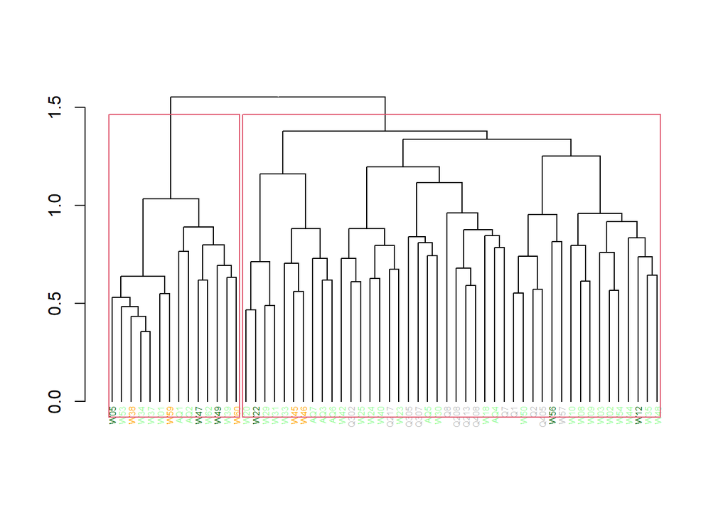

```r
cluster1_plotIDS <- plots %>%
    filter(cluster == 1,
           type_FT != "wet",
           type_FT != "E") %>%
    pull(plotID)

cluster1_treeComm <- treeComm_stem[rownames(treeComm_stem) %in% cluster1_plotIDS,] %>%
    select_if(colSums(.)>0)

cluster1_treeComm_hclust <- cluster1_treeComm %>%
    vegdist(method = "bray") %>%
    hclust(method = "ward.D2")

cluster1_treeComm_dendro <- cluster1_treeComm_hclust %>%
    as.dendrogram() %>%
    color_labels(col = col_plotType[
        match(cluster1_treeComm_hclust$labels, plots$plotID)
    ][cluster1_treeComm_hclust$order])

labels_cex(cluster1_treeComm_dendro) <- 0.5

cluster1_treeComm_clusters <- cutree(cluster1_treeComm_hclust, k = 2)

plot(cluster1_treeComm_dendro);
rect.dendrogram(cluster1_treeComm_dendro,
                k = 2,
                lower_rect = -0.08)
```

```r
cluster1_treeComm_clusters_isa <- indicspecies::multipatt(
    cluster1_treeComm, cluster1_treeComm_clusters
)

summary(cluster1_treeComm_clusters_isa)
```

```
##
##  Multilevel pattern analysis
##  ---------------------------
##
##  Association function: IndVal.g
##  Significance level (alpha): 0.05
##
##  Total number of species: 273
##  Selected number of species: 5
##  Number of species associated to 1 group: 5
##
##  List of species associated to each combination:
##
##  Group 1  #sps.  4
##                           stat p.value
## Epicharis cuneata        0.535   0.005 **
## Artocarpus dadah         0.463   0.010 **
## Planchonella malaccensis 0.463   0.015 *
## Knema intermedia         0.451   0.030 *
##
##  Group 2  #sps.  1
##                           stat p.value
## Calophyllum pulcherrimum 0.625   0.015 *
## ---
## Signif. codes:  0 '***' 0.001 '**' 0.01 '*' 0.05 '.' 0.1 ' ' 1
```